# VIBRANT clinical data - merging CRFs data into wide tables

Author

Laura Vermeren, Laura Symul

Published

July 2, 2026

The purpose of this document is to create, from the data prepared in previous documents, two tables collating participant-invariant (`participant_crfs_merged`) or time-varying (`visits_crfs_merged`) variables collected across CRFs. Specifically, this document creates

- `participant_crfs_merged`: a table with one row per `pid` containing participant-invariant data collected from CRFs that were filled out only once per participant.
- `visits_crfs_merged` : a table with one row per `pid` and `visit_code` with harmonized data from CRFs that were filled out at multiple visits.

```r
data_dir <- get_01_output_dir()

crf_clean_file <- data_dir |>
  fs::dir_ls() |>
  str_subset("01_crf_clean") |>
  sort(decreasing = TRUE) |>
  magrittr::extract(1)
load(crf_clean_file, verbose = TRUE)
```

```
Loading objects:
  crf_clean
```

```r
crf_clean |> names()
```

```
 [1] "crf1"          "crf101"        "crf2"          "crf102"
 [5] "crf3"          "crf4"          "crf5"          "crf6"
 [9] "crf7"          "crf8"          "crf9"          "crf10"
[13] "crf11"         "crf12"         "crf13"         "crf14"
[17] "crf15"         "crf16"         "crf17"         "crf18"
[21] "crf19"         "crf20"         "crf21"         "crf22"
[25] "crf23"         "crf24"         "crf25"         "crf26"
[29] "crf27"         "crf27_long"    "crf28"         "crf29"
[33] "crf29_summary" "crf30"         "crf31"         "crf32"
[37] "crf33"         "crf34"         "crf35"         "crf40"
[41] "crf41"         "crf42"         "crf43"         "crf44"
[45] "crf45"         "crf46"         "crf47"         "crf47_long"
```

```r
rm(crf_clean_file)
```

# `participant_crfs_merged` table

The participant-invariant variables were expected to be found in the following CRFs, which were supposed to be filled only once per participant:

```r
participants_crf_name <-
  c(
    "crf1",
    "crf101",
    "crf2",
    "crf102",
    "crf5",
    "crf6",
    "crf7",
    "crf8",
    "crf9",
    "crf10",
    "crf11",
    "crf12",
    "crf13",
    "crf15",
    "crf22",
    "crf23",
    "crf24",
    "crf25",
    "crf28",
    "crf43",
    "crf44",
    "crf46"
  )
participants_crf_name
```

```
 [1] "crf1"   "crf101" "crf2"   "crf102" "crf5"   "crf6"   "crf7"   "crf8"
 [9] "crf9"   "crf10"  "crf11"  "crf12"  "crf13"  "crf15"  "crf22"  "crf23"
[17] "crf24"  "crf25"  "crf28"  "crf43"  "crf44"  "crf46"
```

Data related to some of those CRFs contained duplicate `pid` values. It appears that some CRFs were filled at several visits and some are in long format.

We need to transform them such that we have a single entry per participant before creating the `participants_crfs_merged` table.

```r
map_df(
  participants_crf_name,
  function(participants_crf_name) {
    df <- crf_clean[[participants_crf_name]]

    if (!"pid" %in% names(df)) {
      return(tibble(crf = participants_crf_name, n_multi_pid = NA_integer_))
    }

    n <-
      df |>
      dplyr::count(pid) |>
      dplyr::filter(n > 1) |>
      nrow()

    tibble(crf = participants_crf_name, n_multi_pid = n)
  }
) |>
  gt()
```

| crf | n_multi_pid |
| --- | --- |
| crf1 | 4 |
| crf101 | 37 |
| crf2 | 4 |
| crf102 | 37 |
| crf5 | 30 |
| crf6 | 41 |
| crf7 | 41 |
| crf8 | 9 |
| crf9 | 9 |
| crf10 | 9 |
| crf11 | 9 |
| crf12 | 9 |
| crf13 | 0 |
| crf15 | 6 |
| crf22 | 55 |
| crf23 | 15 |
| crf24 | 87 |
| crf25 | 87 |
| crf28 | 130 |
| crf43 | 0 |
| crf44 | 0 |
| crf46 | 1 |

## Harmonizing CRFs data for participants with multiple entries

Below, we create a function that, for each CRF in the participants table, compares the rows corresponding to duplicate `pid`s.

If the rows are identical (*i.e.*, they have the same values for all columns except `visit_code` and `study_day`), only one row is kept.

If the rows are not identical, they remain in the CRF and will be manually reviewed later.

```r
process_crf_duplicates <- function(crf_clean, participants_crf_name) {
  participants_crf_filtered <-
    crf_clean[names(crf_clean) %in% participants_crf_name]

  for (crf_name in participants_crf_name) {
    data <- crf_clean[[crf_name]]

    dup_pid <-
      data |>
      dplyr::count(pid) |>
      dplyr::filter(n > 1) |>
      pull(pid)

    if (!("study_day" %in% names(data))) {
      data <-
        data |>
        mutate(study_day = NA_integer_)
    }
    if (!("dfseq" %in% names(data))) {
      data <-
        data |>
        mutate(dfseq = NA_integer_)
    }

    if (!("visit_code" %in% names(data))) {
      data <-
        data |>
        mutate(visit_code = NA_integer_)
    }
    if (!("uid" %in% names(data))) {
      data <-
        data |>
        mutate(uid = NA_character_)
    }

    if (length(dup_pid) > 0) {
      data <-
        data |>
        distinct(across(-c(dfseq, study_day, visit_code, uid)), .keep_all = TRUE)

      participants_crf_filtered[[crf_name]] <- data
    } else {
      participants_crf_filtered[[crf_name]] <- data #|> select(-c(dfseq, study_day))
    }
  }

  return(participants_crf_filtered)
}

participants_crf <- process_crf_duplicates(crf_clean, participants_crf_name)
```

A list of CRFs that still contain duplicate entries is displayed below. These will be examined manually.

```r
map_df(
  participants_crf_name,
  function(participants_crf_name) {
    df <- participants_crf[[participants_crf_name]]

    if (!"pid" %in% names(df)) {
      return(tibble(crf = participants_crf_name, n_multi_pid = NA_integer_))
    }

    n <-
      df |>
      dplyr::count(pid) |>
      dplyr::filter(n > 1) |>
      nrow()

    tibble(crf = participants_crf_name, n_multi_pid = n)
  }
) |>
  gt()
```

| crf | n_multi_pid |
| --- | --- |
| crf1 | 2 |
| crf101 | 15 |
| crf2 | 3 |
| crf102 | 10 |
| crf5 | 30 |
| crf6 | 39 |
| crf7 | 28 |
| crf8 | 5 |
| crf9 | 1 |
| crf10 | 3 |
| crf11 | 6 |
| crf12 | 3 |
| crf13 | 0 |
| crf15 | 4 |
| crf22 | 54 |
| crf23 | 15 |
| crf24 | 51 |
| crf25 | 44 |
| crf28 | 18 |
| crf43 | 0 |
| crf44 | 0 |
| crf46 | 1 |

We review each of these CRFs and decide how to handle the duplicate entries.

### CRF 1

For this CRF, we keep the first observation for each participant since it’s the only that contains data.

We also remove the participants from CAP (that do not have data fill in this CRF) and set the `site` variable to `"MGH"` for all participants.

```r
participants_crf[["crf1"]] <-
  participants_crf[["crf1"]] |>
  mutate(site = "MGH")

pid_temp <-
  participants_crf[["crf1"]] |>
  dplyr::count(pid) |>
  dplyr::filter(n > 1) |>
  pull(pid)

participants_crf[["crf1"]] |>
  dplyr::filter(pid %in% pid_temp) |>
  group_by(pid) |>
  gt(row_group_as_column = TRUE)
```

|  | uid | visit_code | dfseq | vdate_fixed | study_day | other_pronoun_specify | other_gender_specify | other_race_specify | other_level_education_specify | Age | What are your oreferred pronouns | What is your gender identity? | race | ethn | edu | site |
| --- | --- | --- | --- | --- | --- | --- | --- | --- | --- | --- | --- | --- | --- | --- | --- | --- |
| 068100053 | 068100053_0000 | 0000 | 0 | FALSE | -15 | NA | NA | NA | NA | 29 | She/Her | Identifies as female | Prefer not to answer | hispanic/latino/spanish | High school degree or equivalent | MGH |
|  | 068100053_0010 | 0010 | 10 | NA | NA | NA | NA | NA | NA | NA | NA | NA | NA | NA | NA | MGH |
| 068100059 | 068100059_0000 | 0000 | 0 | FALSE | -6 | NA | NA | NA | NA | 22 | She/Her | Identifies as female | White | hispanic/latino/spanish | Some college | MGH |
|  | 068100059_0010 | 0010 | 10 | NA | NA | NA | NA | NA | NA | NA | NA | NA | NA | NA | NA | MGH |

```r
# Remove CAP participant : pid starts with 06820
participants_crf[["crf1"]] <-
  participants_crf[["crf1"]] |>
  filter(!str_starts(pid, "06820")) |>
  group_by(pid) |>
  arrange(dfseq) |>
  slice_head(n = 1) |>
  ungroup() |>
  mutate(
    site = "MGH"
  )
```

### CRF 101

For one specific case (`pid = 200156`), the `income_sources` variable is corrected manually.

Then, for each duplicated `pid`, the data are merged as follows:

- For all variables except `edu` and `income_sources`, we keep the **first recorded value**.
- For `edu`, we keep the **highest education level**, using the order defined in `education_levels` (`Primary school` < `Secondary school` < `Tertiary education`).
- For `income_sources`, we keep the **most complete response**, identified as the one containing the largest number of income sources (based on the number of commas).

Finally, the `site` variable is set to `"CAP"`

```r
# CRF101

# 2 MGH participants are found in the data but should not (CRF101 should only contain data from CAP participants)
# These two MGH participants have empty entries in CRF101, so we remove these entries
participants_crf[["crf101"]] <-
  participants_crf[["crf101"]] |>
  filter(!str_starts(pid, "06810"))

pid_temp <-
  participants_crf[["crf101"]] |>
  dplyr::count(pid) |>
  dplyr::filter(n > 1) |>
  pull(pid)

participants_crf[["crf101"]] |>
  dplyr::filter(pid %in% pid_temp) |>
  group_by(pid) |>
  gt(row_group_as_column = TRUE)
```

|  | uid | visit_code | dfseq | vdate_fixed | study_day | age | What are your preferred pronouns | What is your gender identity | race | edu | income_sources |
| --- | --- | --- | --- | --- | --- | --- | --- | --- | --- | --- | --- |
| 068200011 | 068200011_0000 | 0000 | 0 | FALSE | -22 | 32 | She/Her | Female | African | Secondary school | husband_provides, social_grants |
|  | 068200011_0010 | 0010 | 10 | FALSE | 0 | 32 | She/Her | Female | African | Tertiary education | family_support, husband_provides, social_grants |
| 068200012 | 068200012_0000 | 0000 | 0 | FALSE | -35 | 29 | She/Her | Female | African | Tertiary education | family_support, social_grants |
|  | 068200012_0010 | 0010 | 10 | FALSE | 0 | 29 | She/Her | Female | African | Tertiary education | family_support, husband_provides, social_grants |
| 068200057 | 068200057_0000 | 0000 | 0 | NA | NA | NA | NA | NA | NA | NA | NA |
|  | 068200057_0010 | 0010 | 10 | FALSE | 0 | 29 | She/Her | Female | African | Secondary school | self_employed, social_grants |
| 068200067 | 068200067_0000 | 0000 | 0 | FALSE | -217 | 19 | She/Her | Female | African | Tertiary education | family_support, social_grants |
|  | 068200067_0010 | 0010 | 10 | FALSE | 0 | 19 | She/Her | Female | African | Secondary school | family_support, social_grants |
| 068200095 | 068200095_0000 | 0000 | 0 | FALSE | -19 | 38 | She/Her | Female | African | Secondary school | family_support, husband_provides, social_grants |
|  | 068200095_0010 | 0010 | 10 | FALSE | 0 | 38 | She/Her | Female | African | Secondary school | family_support, social_grants |
| 068200148 | 068200148_0000 | 0000 | 0 | FALSE | -152 | 22 | She/Her | Female | African | Secondary school | family_support, social_grants |
|  | 068200148_0010 | 0010 | 10 | NA | NA | NA | NA | NA | NA | NA | NA |
| 068200154 | 068200154_0000 | 0000 | 0 | FALSE | -28 | 28 | She/Her | Female | African | Tertiary education | husband_provides, social_grants |
|  | 068200154_0010 | 0010 | 10 | FALSE | 0 | 28 | She/Her | Female | African | Tertiary education | social_grants |
| 068200156 | 068200156_0000 | 0000 | 0 | FALSE | -18 | 32 | She/Her | Female | African | Secondary school | employed_full_time, family_support, husband_provides |
|  | 068200156_0010 | 0010 | 10 | FALSE | 0 | 32 | She/Her | Female | African | Secondary school | social_grants |
| 068200162 | 068200162_0000 | 0000 | 0 | FALSE | -24 | 19 | She/Her | Female | African | Secondary school | family_support, husband_provides, social_grants |
|  | 068200162_0010 | 0010 | 10 | FALSE | 0 | 19 | She/Her | Female | African | Secondary school | family_support, social_grants |
| 068200169 | 068200169_0000 | 0000 | 0 | FALSE | -21 | NA | She/Her | Female | African | Tertiary education | family_support, husband_provides |
|  | 068200169_0010 | 0010 | 10 | FALSE | 0 | 24 | She/Her | Female | African | Tertiary education | family_support, husband_provides |
| 068200173 | 068200173_0000 | 0000 | 0 | FALSE | -18 | 23 | She/Her | Female | African | Secondary school | employed_part_time, husband_provides, social_grants |
|  | 068200173_0010 | 0010 | 10 | FALSE | 0 | 23 | She/Her | Female | African | Secondary school | social_grants |
| 068200255 | 068200255_0000 | 0000 | 0 | FALSE | -92 | 25 | She/Her | Female | African | Secondary school | family_support, husband_provides, social_grants |
|  | 068200255_0010 | 0010 | 10 | FALSE | 0 | 26 | She/Her | Female | African | Secondary school | family_support, husband_provides, social_grants |
| 068200278 | 068200278_0000 | 0000 | 0 | FALSE | -54 | 25 | She/Her | Female | African | Secondary school | family_support, husband_provides, social_grants |
|  | 068200278_0010 | 0010 | 10 | FALSE | -21 | 26 | She/Her | Female | African | Secondary school | family_support, husband_provides, social_grants |
| 068200288 | 068200288_0000 | 0000 | 0 | FALSE | -84 | 19 | She/Her | Female | African | Secondary school | family_support, social_grants |
|  | 068200288_0010 | 0010 | 10 | FALSE | 0 | 20 | She/Her | Female | African | Secondary school | family_support, social_grants |
| 068200350 | 068200350_0000 | 0000 | 0 | FALSE | -14 | 32 | She/Her | Female | African | Secondary school | family_support, husband_provides, social_grants |
|  | 068200350_0010 | 0010 | 10 | FALSE | -7 | 32 | She/Her | Female | African | Secondary school | family_support, social_grants |

```r
# 30 participants with double pid

education_levels <- c(
  "No schooling",
  "Primary school",
  "Secondary school",
  "Tertiary education",
  "Other"
)

participants_crf[["crf101"]] <-
  participants_crf[["crf101"]] |>
  mutate(
    income_sources = case_when(
      pid == "200156" ~ "employed_full_time, family_support, husband_provides, social_grants",
      TRUE ~ income_sources
    )
  ) |>
  group_by(pid) |>
  summarise(
    # For all variables except edu & income_sources, we take the first value
    across(
      .cols = !any_of(c("edu", "income_sources")),
      .fns = ~ dplyr::first(.x)
    ),

    # For edu : we take the highest values
    edu = {
      if (all(is.na(edu))) {
        NA_character_
      } else {
        edu_non_na <- edu[!is.na(edu)]
        matches <- match(edu_non_na, education_levels)
        edu_non_na[which.max(matches)]
      }
    },

    # For income_sources : we take the most complete entry
    income_sources = {
      if (all(is.na(income_sources))) {
        NA_character_
      } else {
        inc_non_na <- income_sources[!is.na(income_sources)]
        counts <- stringr::str_count(inc_non_na, ",") + 1
        inc_non_na[which.max(counts)]
      }
    },

    .groups = "drop"
  ) |>
  mutate(site = "CAP")

rm(pid_temp, education_levels)
```

We combine the demographics data from `crf1` and `crf101` into a single table called `crf1_101`.

```r
participants_crf[["crf1_101"]] <- bind_rows(
  participants_crf[["crf1"]],
  participants_crf[["crf101"]]
)

#remove crf1 and 101 from the participant_crf
participants_crf[["crf1"]] <- NULL
participants_crf[["crf101"]] <- NULL
```

### CRF 2

For participants with duplicate entries, if they ever reported being worried for any of the ‘worry’ variables, we retain the ‘Checked’ value (worst-case scenario).

The CRF also contains some participants from CAP, who do not have data in this CRF, we remove them.

```r
# CRF2

pid_temp <-
  participants_crf[["crf2"]] |>
  dplyr::count(pid) |>
  dplyr::filter(n > 1) |>
  pull(pid)

participants_crf[["crf2"]] |>
  dplyr::filter(pid %in% pid_temp) |>
  group_by(pid) |>
  gt(row_group_as_column = TRUE)
```

|  | uid | visit_code | Visit code | additional_income | annual_gross_income | Worry enough money - food | Worry enough money-utilities | Worry enough money -rent | Worry enough money-student loans | Worry enough money-education fees | Worry enough money-mortgage | Worry enough money-childcare | Worry enough money-medical bills | Worry enough money-none of the above | primary_income | additional_income_type | study_day |
| --- | --- | --- | --- | --- | --- | --- | --- | --- | --- | --- | --- | --- | --- | --- | --- | --- | --- |
| 068100019 | 068100019_0000 | 0000 | 0 | No | $70,000 - $140,000 | Unchecked | Unchecked | Unchecked | Unchecked | Checked | Unchecked | Unchecked | Unchecked | Unchecked | employed_full | No additional income | NA |
|  | 068100019_0010 | 0010 | 10 | No | $70,000 - $140,000 | Unchecked | Unchecked | Unchecked | Checked | Unchecked | Unchecked | Unchecked | Unchecked | Unchecked | employed_full | No additional income | NA |
| 068100053 | 068100053_0000 | 0000 | 0 | No | $30.000 - $70,000 | Checked | Unchecked | Unchecked | Unchecked | Unchecked | Unchecked | Unchecked | Unchecked | Unchecked | employed_full, wic | No additional income | NA |
|  | 068100053_0010 | 0010 | 10 | NA | NA | NA | NA | NA | NA | NA | NA | NA | NA | NA | NA | NA | NA |
| 068100059 | 068100059_0000 | 0000 | 0 | Yes | $70,000 - $140,000 | Checked | Unchecked | Unchecked | Unchecked | Checked | Checked | Unchecked | Unchecked | Unchecked | employed_full | employed_part | NA |
|  | 068100059_0010 | 0010 | 10 | NA | NA | NA | NA | NA | NA | NA | NA | NA | NA | NA | NA | NA | NA |

```r
# 6 participants with double pid

# if worry was "checked" and "uncheked" keep the worry "checked"
worry_cols <- names(participants_crf[["crf2"]])[str_detect(
  names(participants_crf[["crf2"]]),
  "^worry_"
)]
other_cols <- setdiff(names(participants_crf[["crf2"]]), c("pid", worry_cols))

participants_crf[["crf2"]] <-
  participants_crf[["crf2"]] |>
  filter(str_starts(pid, "06810")) |> # keep only MGH participants
  group_by(pid) |>
  summarise(
    across(all_of(other_cols), ~ dplyr::first(.x)),
    across(all_of(worry_cols), ~ if ("Checked" %in% .x) "Checked" else "Unchecked"),
    .groups = "drop"
  )

rm(pid_temp, worry_cols, other_cols)
```

### CRF 102

The duplicate entries have incoherent response for the `monthly_gross_income` variable. We decide to keep the most recent visit.

These CRF also contains some participants from MGH, who do not have data in this CRF, we remove them.

```r
#crf102

pid_temp <-
  participants_crf[["crf102"]] |>
  dplyr::count(pid) |>
  dplyr::filter(n > 1) |>
  pull(pid)

participants_crf[["crf102"]] |>
  dplyr::filter(pid %in% pid_temp) |>
  group_by(pid) |>
  gt(row_group_as_column = TRUE)
```

|  | uid | visit_code | Visit code | monthly_gross_income | Ever worry about - food | Ever worry about - utilities | Ever worry about - rent | Ever worry about - student loans | Ever worry about - education loans | Ever worry about - mortgage | Ever worry about - childcare | Ever worry about - medical bills | Ever worry about - none of above | study_day |
| --- | --- | --- | --- | --- | --- | --- | --- | --- | --- | --- | --- | --- | --- | --- |
| 068200008 | 068200008_0000 | 0000 | 0 | > R3500 | Checked | Unchecked | Unchecked | Unchecked | Checked | Unchecked | Unchecked | Unchecked | Unchecked | NA |
|  | 068200008_0010 | 0010 | 10 | R1001-R3500 per month | Unchecked | Unchecked | Unchecked | Unchecked | Unchecked | Unchecked | Unchecked | Checked | Unchecked | NA |
| 068200012 | 068200012_0000 | 0000 | 0 | R1001-R3500 per month | Unchecked | Unchecked | Unchecked | Unchecked | Checked | Unchecked | Unchecked | Unchecked | Unchecked | NA |
|  | 068200012_0010 | 0010 | 10 | Less than R1000 per month | Unchecked | Unchecked | Unchecked | Unchecked | Checked | Unchecked | Unchecked | Unchecked | Unchecked | NA |
| 068200057 | 068200057_0000 | 0000 | 0 | NA | NA | NA | NA | NA | NA | NA | NA | NA | NA | NA |
|  | 068200057_0010 | 0010 | 10 | R1001-R3500 per month | Checked | Unchecked | Unchecked | Checked | Checked | Unchecked | Checked | Checked | Unchecked | NA |
| 068200067 | 068200067_0000 | 0000 | 0 | R1001-R3500 per month | Checked | Checked | Unchecked | Unchecked | Unchecked | Unchecked | Unchecked | Unchecked | Unchecked | NA |
|  | 068200067_0010 | 0010 | 10 | Prefer not to answer | Unchecked | Unchecked | Unchecked | Unchecked | Unchecked | Unchecked | Unchecked | Unchecked | Checked | NA |
| 068200095 | 068200095_0000 | 0000 | 0 | > R3500 | Checked | Unchecked | Unchecked | Unchecked | Unchecked | Unchecked | Checked | Unchecked | Unchecked | NA |
|  | 068200095_0010 | 0010 | 10 | Less than R1000 per month | Checked | Unchecked | Unchecked | Unchecked | Unchecked | Unchecked | Checked | Unchecked | Unchecked | NA |
| 068200125 | 068200125_0000 | 0000 | 0 | R1001-R3500 per month | Checked | Unchecked | Unchecked | Unchecked | Unchecked | Unchecked | Checked | Unchecked | Unchecked | NA |
|  | 068200125_0010 | 0010 | 10 | Less than R1000 per month | Checked | Unchecked | Unchecked | Unchecked | Unchecked | Unchecked | Checked | Unchecked | Unchecked | NA |
| 068200131 | 068200131_0000 | 0000 | 0 | Less than R1000 per month | Checked | Unchecked | Unchecked | Unchecked | Unchecked | Unchecked | Unchecked | Unchecked | Unchecked | NA |
|  | 068200131_0010 | 0010 | 10 | R1001-R3500 per month | Checked | Unchecked | Unchecked | Unchecked | Unchecked | Unchecked | Unchecked | Unchecked | Unchecked | NA |
| 068200148 | 068200148_0000 | 0000 | 0 | > R3500 | Checked | Unchecked | Unchecked | Unchecked | Unchecked | Unchecked | Unchecked | Unchecked | Unchecked | NA |
|  | 068200148_0010 | 0010 | 10 | NA | NA | NA | NA | NA | NA | NA | NA | NA | NA | NA |
| 068200156 | 068200156_0000 | 0000 | 0 | > R3500 | Checked | Unchecked | Unchecked | Unchecked | Checked | Unchecked | Unchecked | Unchecked | Unchecked | NA |
|  | 068200156_0010 | 0010 | 10 | > R3500 | Unchecked | Unchecked | Unchecked | Unchecked | Checked | Unchecked | Unchecked | Unchecked | Unchecked | NA |
| 068200327 | 068200327_0000 | 0000 | 0 | Prefer not to answer | Unchecked | Unchecked | Checked | Unchecked | Unchecked | Unchecked | Unchecked | Unchecked | Unchecked | NA |
|  | 068200327_0010 | 0010 | 10 | Less than R1000 per month | Checked | Unchecked | Unchecked | Unchecked | Unchecked | Unchecked | Unchecked | Unchecked | Unchecked | NA |

```r
participants_crf[["crf102"]] <-
  participants_crf[["crf102"]] |>
  filter(str_starts(pid, "06820")) |> # keep only CAP participants
  group_by(pid) |>
  arrange(-dfseq) |>
  slice_head(n = 1) |>
  ungroup()

rm(pid_temp)
```

We combine the socio demographics data from `crf2` and `crf102` into a single table called `crf2_102`.

```r
participants_crf[["crf2_102"]] <- bind_rows(
  participants_crf[["crf2"]],
  participants_crf[["crf102"]]
)

# Remove crf2 and 102 from the participant_crf
participants_crf[["crf2"]] <- NULL
participants_crf[["crf102"]] <- NULL
```

### CRF 5

For each duplicated participant, the rows are merged while preserving all relevant information.  
The following rules are applied during summarization:

- **`no_pre_existing_condition`**:  
  If all entries are identical, the unique value is kept.  
  Otherwise, all unique values are concatenated with `" & "`.
- **`diagnosis_agg`**:  
  All reported diagnoses are concatenated with `" & "`.
- **`ongoing_enrollment`** and **`ongoing_at_exit`**:  
  If all entries are identical, the unique value is kept.  
  Otherwise, the function checks for inconsistencies between `ongoing_enrollment` (or `ongoing_at_exit`) and the corresponding `diagnosis`.  
  When differences are found, both the value and the related diagnosis are combined in the format  
  *`value (diagnosis)`*, and multiple such entries are concatenated with `" & "`.

```r
pid_temp <-
  participants_crf[["crf5"]] |>
  dplyr::count(pid) |>
  dplyr::filter(n > 1) |>
  pull(pid)

participants_crf[["crf5"]] |>
  dplyr::filter(pid %in% pid_temp) |>
  group_by(pid) |>
  gt(row_group_as_column = TRUE)
```

|  | no_pre_existing_condition | diagnosis | Condition ongoing et enrollment | Condition ongoing at study exit | study_day | dfseq | visit_code | uid |
| --- | --- | --- | --- | --- | --- | --- | --- | --- |
| 068100010 | FALSE | Shelfish allergy | Yes | Yes | NA | NA | NA | NA |
|  | FALSE | Fruit allergy | Yes | Yes | NA | NA | NA | NA |
|  | FALSE | Egg allergy | Yes | Yes | NA | NA | NA | NA |
|  | FALSE | Latex allergy | Yes | Yes | NA | NA | NA | NA |
|  | FALSE | Asthma | Yes | Yes | NA | NA | NA | NA |
|  | FALSE | Depression with anxiety | Yes | Yes | NA | NA | NA | NA |
|  | FALSE | Eczema | Yes | Yes | NA | NA | NA | NA |
| 068100011 | FALSE | Eczema | Yes | Yes | NA | NA | NA | NA |
|  | FALSE | Asthma | Yes | Yes | NA | NA | NA | NA |
|  | FALSE | Peanut allergy | Yes | Yes | NA | NA | NA | NA |
| 068100013 | FALSE | Shellfish allergy | Yes | Yes | NA | NA | NA | NA |
|  | FALSE | Rosacea | Yes | Yes | NA | NA | NA | NA |
|  | FALSE | Major depressive disorder | Yes | Yes | NA | NA | NA | NA |
|  | FALSE | Atopic dermatitis | Yes | Yes | NA | NA | NA | NA |
| 068100014 | FALSE | Asthma | Yes | Yes | NA | NA | NA | NA |
|  | FALSE | Attention deficit disorder | Yes | Yes | NA | NA | NA | NA |
|  | FALSE | Major depressive disorder (mdd) | Yes | Yes | NA | NA | NA | NA |
| 068100026 | FALSE | Attention deficit hyperactivity disorder | Yes | Yes | NA | NA | NA | NA |
|  | FALSE | Anxety | Yes | Yes | NA | NA | NA | NA |
|  | FALSE | Depression | Yes | Yes | NA | NA | NA | NA |
|  | FALSE | Type 2 diabetes mellitus | Yes | Yes | NA | NA | NA | NA |
| 068100033 | FALSE | Rheumatoid arthritis | Yes | Yes | NA | NA | NA | NA |
|  | FALSE | Eczema | Yes | Yes | NA | NA | NA | NA |
|  | FALSE | Anxiety | Yes | Yes | NA | NA | NA | NA |
|  | FALSE | Asthma | Yes | Yes | NA | NA | NA | NA |
|  | FALSE | Adhd | Yes | Yes | NA | NA | NA | NA |
|  | FALSE | Depression | Yes | Yes | NA | NA | NA | NA |
|  | FALSE | Mixed connctive tissue disease | Yes | Yes | NA | NA | NA | NA |
| 068100044 | FALSE | High cholesterol and elevated hdl | Blank | Yes | NA | NA | NA | NA |
|  | FALSE | Herpes simplex type 2 | Yes | Yes | NA | NA | NA | NA |

[output cut: 55 more lines]

```r
participants_crf[["crf5"]] <-
  participants_crf[["crf5"]] |>
  group_by(pid) |>
  summarise(
    no_pre_existing_condition = if (length(unique(no_pre_existing_condition)) == 1) {
      unique(no_pre_existing_condition)
    } else {
      paste(unique(no_pre_existing_condition), collapse = " & ")
    },

    diagnosis_agg = paste(diagnosis, collapse = " & "),

    ongoing_enrollment = {
      if (length(unique(ongoing_enrollment)) == 1) {
        unique(ongoing_enrollment)
      } else {
        paste(
          sapply(1:n(), function(i) {
            if (ongoing_enrollment[i] != ongoing_enrollment[1]) {
              paste0(ongoing_enrollment[i], " (", diagnosis[i], ")")
            } else {
              ongoing_enrollment[i]
            }
          }),
          collapse = " & "
        ) |>
          unique()
      }
    },
    ongoing_at_exit = if (length(unique(ongoing_at_exit)) == 1) {
      unique(ongoing_at_exit)
    } else {
      paste(
        sapply(1:n(), function(i) {
          if (ongoing_at_exit[i] != ongoing_at_exit[1]) {
            paste0(ongoing_at_exit[i], " (", diagnosis[i], ")")
          } else {
            ongoing_at_exit[i]
          }
        }),
        collapse = " & "
      ) |>
        unique()
    }
  )
```

### CRF 6

We keep the values of the most recent visit.

```r
# crf6

pid_temp <-
  participants_crf[["crf6"]] |>
  dplyr::count(pid) |>
  dplyr::filter(n > 1) |>
  pull(pid)
pid_temp
```

```
 [1] "068100009" "068100019" "068100053" "068100059" "068200008" "068200009"
 [7] "068200011" "068200012" "068200017" "068200037" "068200038" "068200057"
[13] "068200067" "068200087" "068200096" "068200128" "068200131" "068200148"
[19] "068200154" "068200156" "068200162" "068200169" "068200172" "068200173"
[25] "068200174" "068200179" "068200201" "068200216" "068200224" "068200255"
[31] "068200256" "068200267" "068200278" "068200279" "068200288" "068200304"
[37] "068200325" "068200327" "068200350"
```

```r
participants_crf[["crf6"]] |>
  dplyr::filter(pid %in% pid_temp) |>
  group_by(pid) |>
  gt(row_group_as_column = TRUE)
```

|  | uid | visit_code | dfseq | vdate_fixed | study_day | Age at consent 18-40 years | Premenopausal | Abnormal nugent score >= 7 | Amesel meets 3 out of 4 criteria | Hiv uninfected | Not pregnant by pregnancy test enroll | On contraceptives that suppres menses | Provide informed consent | Willing attend study visits | History uterine disease | Prior hysterectomy | Cervicovaginal infection | Yeast infection | Use oral or vaginal antibiotics | Syphilis positive at enrollment | Contraindication to metronidazole | High grade abnormal pap | Currently in another ip study | Use long-acting ip product |
| --- | --- | --- | --- | --- | --- | --- | --- | --- | --- | --- | --- | --- | --- | --- | --- | --- | --- | --- | --- | --- | --- | --- | --- | --- |
| 068100009 | 068100009_0000 | 0000 | 0 | FALSE | -133 | Yes | Yes | Not done | No | Not done | Yes | Yes | Yes | Yes | No | No | No | No | No | Not done | No | Not applicable | No | No |
|  | 068100009_0010 | 0010 | 10 | FALSE | 0 | Yes | Yes | Not done | No | Not done | Yes | Yes | Yes | Yes | No | No | Not done | No | No | Not done | No | Blank | No | No |
| 068100019 | 068100019_0000 | 0000 | 0 | FALSE | -19 | Yes | Yes | Blank | No | Not done | Yes | Yes | Yes | Yes | No | No | Not done | Yes | No | Not done | No | Blank | No | No |
|  | 068100019_0010 | 0010 | 10 | FALSE | 0 | Yes | Yes | Not done | No | Not done | Yes | Yes | Yes | Yes | No | No | Not done | No | No | Not done | No | Blank | No | No |
| 068100053 | 068100053_0000 | 0000 | 0 | FALSE | -15 | Yes | Yes | No | Blank | Not done | Yes | Not applicable | Yes | Yes | No | No | Not done | Yes | No | Not done | No | Blank | No | No |
|  | 068100053_0010 | 0010 | 10 | FALSE | -7 | Yes | Yes | Yes | Yes | Yes | Yes | Not applicable | Yes | Yes | No | No | No | No | No | No | No | Blank | No | No |
| 068100059 | 068100059_0000 | 0000 | 0 | FALSE | -6 | Yes | Yes | Not done | Yes | Not done | Yes | Not applicable | Yes | Yes | No | No | Not done | Yes | No | Not done | No | Blank | No | No |
|  | 068100059_0010 | 0010 | 10 | FALSE | 0 | Yes | Yes | Not done | No | Not done | Yes | Not applicable | Yes | Yes | No | No | Not done | No | No | Not done | No | Blank | No | No |
| 068200008 | 068200008_0000 | 0000 | 0 | FALSE | -37 | Yes | Yes | Yes | No | Not done | Not done | Not done | Yes | Yes | Not done | Not done | Not done | Not done | Not done | Not done | Not done | Not done | Not done | Not done |
|  | 068200008_0010 | 0010 | 10 | FALSE | -8 | Yes | Yes | Yes | Yes | Yes | Yes | Yes | Yes | Yes | No | No | No | No | No | No | No | No | No | No |
| 068200009 | 068200009_0000 | 0000 | 0 | FALSE | -13 | Yes | Yes | Yes | No | Not done | Not done | Yes | Yes | Yes | Not done | Not done | Not done | Not required | Not done | Not done | Not done | Not done | No | Not done |
|  | 068200009_0010 | 0010 | 10 | FALSE | 0 | Yes | Yes | Blank | No | Not done | Not done | Yes | Yes | Yes | Not done | Not done | Not done | Not done | Not done | Not done | Not done | Not done | No | Not done |
| 068200011 | 068200011_0000 | 0000 | 0 | FALSE | -22 | Yes | Yes | Yes | No | Not done | Not done | Yes | Yes | Yes | Not done | Not done | Not done | Not done | Not done | Not done | Not done | Not done | No | Not done |
|  | 068200011_0010 | 0010 | 10 | FALSE | 0 | Yes | Yes | Yes | Yes | Yes | Not done | Yes | Yes | Yes | No | No | No | Not done | No | Yes | No | No | No | No |
| 068200012 | 068200012_0000 | 0000 | 0 | FALSE | -35 | Yes | Yes | Blank | No | Not done | Not done | Yes | Yes | Yes | Not done | Not done | Not done | Not done | Not done | Not done | Not done | Not done | No | Not done |
|  | 068200012_0010 | 0010 | 10 | FALSE | 0 | Yes | Yes | Yes | Yes | Yes | Yes | Yes | Yes | Yes | Not done | Not done | Yes | Not done | Not done | Not done | Not done | Blank | No | No |
| 068200017 | 068200017_0000 | 0000 | 0 | FALSE | -36 | Yes | Yes | Not applicable | No | Not done | Not done | Yes | Yes | Yes | Not done | Not done | Not done | Not done | Not done | Not done | Not done | Not done | No | Not done |
|  | 068200017_0010 | 0010 | 10 | FALSE | 0 | Yes | Yes | No | No | Not done | Not done | Not done | Yes | Yes | Not done | Not done | Not done | Not done | Not done | Not done | Not done | Blank | Not done | Not done |
| 068200037 | 068200037_0000 | 0000 | 0 | FALSE | -26 | Yes | Yes | No | No | Not done | Not done | Yes | Yes | Yes | Not done | Not done | Not done | Not done | Not done | Not done | Not done | Not done | No | Not done |
|  | 068200037_0010 | 0010 | 10 | FALSE | 0 | Yes | Yes | No | No | Yes | Not done | Yes | Yes | Yes | Not done | Not done | Not done | Not done | Not done | Not done | Not done | Not done | No | Not done |
| 068200038 | 068200038_0000 | 0000 | 0 | FALSE | -30 | Not applicable | Not applicable | Not applicable | Not applicable | Not done | Not done | No | Not applicable | Not applicable | Not applicable | Not applicable | Not applicable | Not applicable | Not applicable | Not applicable | Not done | Not applicable | Not applicable | Not applicable |
|  | 068200038_0010 | 0010 | 10 | FALSE | 0 | Yes | Yes | No | No | Not done | Yes | Yes | Yes | Yes | Not done | Not done | Not done | Not done | Not done | Not done | Not done | Not applicable | Not done | Not done |
| 068200057 | 068200057_0000 | 0000 | 0 | FALSE | -35 | Yes | Yes | Not done | Not done | Not done | Not done | Not done | Yes | No | Not done | Not done | Not done | Not done | Not done | Not done | Not done | Not done | No | Not done |
|  | 068200057_0010 | 0010 | 10 | FALSE | 0 | Yes | Yes | Yes | No | No | Not done | Yes | Yes | Yes | Not done | Not done | Not done | Not done | Yes | Not done | Not done | Not done | No | Not done |
| 068200067 | 068200067_0000 | 0000 | 0 | FALSE | -217 | Yes | Yes | Yes | No | Yes | Not done | Yes | Yes | Yes | Not done | Not done | Not done | Not done | Not done | Not done | Not done | Not done | No | Not done |
|  | 068200067_0010 | 0010 | 10 | FALSE | 0 | Yes | Yes | Yes | Yes | Yes | Not done | Yes | Yes | Yes | Not done | Not done | Not done | Not done | Not done | Not done | Not done | Blank | Not done | Not done |
| 068200087 | 068200087_0000 | 0000 | 0 | FALSE | -21 | Yes | Yes | Yes | No | Yes | Not done | Yes | Yes | Yes | Not done | Not done | Not done | Not done | Not done | Not done | Not done | Not done | No | Not required |
|  | 068200087_0010 | 0010 | 10 | FALSE | -5 | Yes | Yes | Yes | Yes | Yes | Yes | Yes | Yes | Yes | No | No | No | No | No | No | No | No | No | No |
| 068200096 | 068200096_0000 | 0000 | 0 | FALSE | -19 | Yes | Yes | Yes | No | Not done | Not done | Not done | Not done | Not done | Not done | Not done | Not done | Not done | Not done | Not done | Not done | Not done | Not done | Not done |
|  | 068200096_0010 | 0010 | 10 | FALSE | 0 | Yes | Yes | Yes | Yes | Not applicable | Not done | Yes | Yes | Yes | Not done | Not done | Not done | Yes | Not done | Not done | Not done | Blank | Not done | Not done |
| 068200128 | 068200128_0000 | 0000 | 0 | FALSE | -12 | Yes | Yes | Yes | No | Yes | Not done | Yes | Yes | Yes | Not done | Not done | Not done | Not done | Not done | Not done | Not done | Not done | No | Not done |
|  | 068200128_0010 | 0010 | 10 | FALSE | 0 | Yes | Yes | No | No | Not done | Not done | Yes | Yes | Yes | Not done | Not done | Not done | Not done | Not done | Not done | Not done | Blank | Not done | Not done |
| 068200131 | 068200131_0000 | 0000 | 0 | FALSE | -23 | Yes | Yes | Yes | No | Yes | Not applicable | Yes | Yes | Yes | Not applicable | Not applicable | Not applicable | Not applicable | Not applicable | Not applicable | Not applicable | Not applicable | No | Not applicable |
|  | 068200131_0010 | 0010 | 10 | FALSE | -9 | Yes | Yes | Yes | Yes | Yes | Yes | Yes | Yes | Yes | No | No | No | No | No | No | No | No | No | No |
| 068200148 | 068200148_0000 | 0000 | 0 | FALSE | -152 | Yes | Yes | Yes | No | Yes | Yes | Yes | Yes | Yes | Not done | Not done | Not done | Not done | Not done | Not done | Not done | Blank | Not done | Not done |
|  | 068200148_0010 | 0010 | 10 | FALSE | 0 | Yes | Not done | Not done | Not done | Not done | Not done | Not done | Yes | No | Not done | Not done | Not done | Not done | Not done | Not done | Not done | Blank | Not done | Not done |
| 068200154 | 068200154_0000 | 0000 | 0 | FALSE | -28 | Yes | Yes | Yes | Yes | Not done | Not done | Yes | Yes | Yes | Not done | Not done | Not done | Not done | Not done | Not done | Not done | Not done | Not done | Not done |
|  | 068200154_0010 | 0010 | 10 | FALSE | 0 | Yes | Yes | No | No | Yes | Not done | Yes | Yes | Yes | Not done | Not done | Not done | Not done | Not done | Not done | Not done | Blank | No | Not done |
| 068200156 | 068200156_0000 | 0000 | 0 | FALSE | -18 | Yes | Yes | Yes | No | Not done | Not done | Yes | Yes | Yes | Not done | Not done | Not done | Not done | Not done | Not done | Not done | Blank | Not done | Not done |
|  | 068200156_0010 | 0010 | 10 | FALSE | 0 | Yes | Yes | Yes | No | Yes | Not done | Yes | Yes | Yes | Not done | Not done | Not done | Not done | Not done | Not done | Not done | Blank | Not done | Not done |
| 068200162 | 068200162_0000 | 0000 | 0 | FALSE | -24 | Yes | Yes | Yes | No | Yes | Not done | Yes | Yes | Yes | Not done | Not done | Not done | Not done | Not done | Not done | Not done | Blank | No | Not done |
|  | 068200162_0010 | 0010 | 10 | FALSE | 0 | Yes | Yes | No | No | Yes | Yes | Yes | Yes | Yes | Not done | Not done | Not done | Not done | Not done | Not done | Not done | Blank | Not done | Not done |
| 068200169 | 068200169_0000 | 0000 | 0 | FALSE | -21 | Yes | Yes | Yes | No | Yes | Not applicable | Yes | Yes | Yes | Not done | Not done | Not done | Not done | Not done | Not done | Not done | Not done | No | Not done |
|  | 068200169_0010 | 0010 | 10 | FALSE | 0 | Yes | Yes | Yes | Yes | Yes | Not done | Yes | Yes | Yes | No | No | Yes | No | Yes | Yes | No | Blank | No | No |
| 068200172 | 068200172_0000 | 0000 | 0 | FALSE | -19 | Yes | Yes | Yes | No | Yes | Not done | Yes | Yes | Yes | Not done | Not done | Not done | Not done | Not done | Not done | Not done | Blank | No | Not done |
|  | 068200172_0010 | 0010 | 10 | FALSE | 0 | Yes | Yes | Yes | Yes | Yes | Yes | Yes | Yes | Yes | Not done | Not done | Yes | Not done | Not done | Not done | Not done | Blank | Not done | Not done |
| 068200173 | 068200173_0000 | 0000 | 0 | FALSE | -18 | Yes | Yes | Yes | No | Not done | Not done | Yes | Yes | Yes | Not done | Not done | Not done | Not done | Not done | Not done | Not done | Not done | Not done | Not done |
|  | 068200173_0010 | 0010 | 10 | FALSE | 0 | Yes | Yes | Yes | Yes | Yes | Not applicable | Yes | Yes | No | No | No | No | No | No | No | No | Blank | No | No |
| 068200174 | 068200174_0000 | 0000 | 0 | FALSE | -41 | Yes | Yes | Yes | No | Yes | Not done | Yes | Yes | Yes | Not done | Not done | Not done | Not done | Not done | Not done | Not done | Blank | Not done | Not done |
|  | 068200174_0010 | 0010 | 10 | FALSE | 0 | Yes | Yes | Blank | No | Yes | Yes | Yes | Yes | Yes | Not done | Not required | Not done | Not done | Not done | Not done | Not done | Blank | Not done | Not done |
| 068200179 | 068200179_0000 | 0000 | 0 | FALSE | -30 | Yes | Yes | Yes | No | Yes | Yes | Yes | Yes | Yes | Not done | Not done | Not done | Not done | Not done | Not done | Not done | Not done | Not done | Not done |
|  | 068200179_0010 | 0010 | 10 | FALSE | -7 | Yes | Yes | Yes | Yes | Yes | Yes | Yes | Yes | Yes | No | No | No | No | No | No | No | Blank | No | No |
| 068200201 | 068200201_0000 | 0000 | 0 | FALSE | -8 | Yes | Yes | Yes | No | Yes | Yes | Yes | Yes | Yes | Not done | Not done | Not done | Not done | Not done | Not done | Not done | Blank | Not done | Not done |
|  | 068200201_0010 | 0010 | 10 | FALSE | 0 | Yes | Yes | Not done | No | Yes | Not done | Yes | Yes | Yes | Not done | Not done | Not done | Yes | Not done | Not done | Not done | Blank | Not done | Not done |
| 068200216 | 068200216_0000 | 0000 | 0 | FALSE | -54 | Yes | Yes | Blank | Yes | Yes | Yes | No | Yes | Yes | Not done | Not done | Not done | Not done | Not done | Not done | Not done | Blank | Not done | Not done |
|  | 068200216_0010 | 0010 | 10 | FALSE | 0 | Yes | Yes | Yes | No | Yes | Not done | Yes | Yes | Yes | Not applicable | Not applicable | Not applicable | Not applicable | Not applicable | Not applicable | Not applicable | Blank | Not applicable | Not applicable |
| 068200224 | 068200224_0000 | 0000 | 0 | FALSE | -13 | Yes | Yes | Yes | No | Yes | Yes | Yes | Yes | Yes | Not done | Not done | Not done | Not done | Not done | Not done | Not done | Blank | Not done | Not done |
|  | 068200224_0010 | 0010 | 10 | FALSE | -6 | Yes | Yes | Yes | Yes | Yes | Yes | Yes | Yes | Yes | No | No | No | No | No | No | No | Blank | No | No |
| 068200255 | 068200255_0000 | 0000 | 0 | FALSE | -92 | Yes | Yes | Yes | No | Yes | Not applicable | Yes | Yes | Yes | Not done | Not done | Not done | Not done | Not done | Not done | Not done | Blank | No | Not done |
|  | 068200255_0010 | 0010 | 10 | FALSE | 0 | Yes | Yes | Yes | Yes | Yes | Yes | Yes | Yes | Yes | No | No | Yes | No | No | No | No | Blank | No | No |
| 068200256 | 068200256_0000 | 0000 | 0 | FALSE | -46 | Yes | Yes | Blank | No | Yes | Not done | Yes | Yes | Yes | Not done | Not done | Not done | Not done | Not done | Not done | Not done | Blank | Not done | Not done |
|  | 068200256_0010 | 0010 | 10 | FALSE | 0 | Yes | Yes | No | No | Yes | Yes | Yes | Yes | Yes | Not done | Not done | Not done | No | Not done | Not done | Not done | Blank | Not done | Not done |
| 068200267 | 068200267_0000 | 0000 | 0 | FALSE | -10 | Yes | Yes | Yes | No | Yes | Not done | Yes | Yes | Yes | Not done | Not done | Not done | Not done | Not done | Not done | Not done | Blank | Not done | Not done |
|  | 068200267_0010 | 0010 | 10 | FALSE | 0 | Yes | Yes | Yes | No | Yes | Yes | Yes | Yes | Yes | Not done | Not done | Not done | Not done | Not done | Not done | Not done | Blank | Not done | Not done |
| 068200278 | 068200278_0000 | 0000 | 0 | FALSE | -53 | Yes | Yes | Yes | Yes | Yes | Yes | Yes | Yes | No | No | No | No | No | No | No | No | Blank | No | No |
|  | 068200278_0010 | 0010 | 10 | FALSE | -21 | Yes | Yes | Yes | Yes | Yes | Yes | Yes | Yes | Yes | No | No | No | No | No | No | No | Blank | No | No |
| 068200279 | 068200279_0000 | 0000 | 0 | FALSE | -8 | Yes | Yes | Yes | No | Yes | Not done | Yes | Yes | Yes | Not done | Not done | Not done | Not done | Not done | Not done | Not done | Blank | Not done | Not done |
|  | 068200279_0010 | 0010 | 10 | FALSE | 0 | Yes | Yes | Yes | Yes | Yes | Yes | Yes | Yes | Yes | Not done | Not done | Yes | No | Not done | Not done | Not done | Blank | Not done | Not done |
| 068200288 | 068200288_0000 | 0000 | 0 | FALSE | -84 | Yes | Yes | Yes | No | Yes | Not done | Yes | Yes | Yes | Not done | Not done | Not done | Not done | Not done | Not done | Not done | Blank | Not done | Not done |
|  | 068200288_0010 | 0010 | 10 | FALSE | 0 | Yes | Yes | Yes | Yes | Yes | Not done | Yes | Yes | Yes | No | No | Yes | Not done | Not done | Not done | Not done | Blank | Not done | Not done |
| 068200304 | 068200304_0000 | 0000 | 0 | FALSE | -14 | Yes | Yes | Yes | No | Yes | Not done | Yes | Yes | Yes | Not done | Not done | Not done | Not done | Not done | Not done | Not done | Blank | Not done | Not done |
|  | 068200304_0010 | 0010 | 10 | FALSE | 0 | Yes | Yes | Yes | Yes | Yes | Not done | Yes | Yes | Yes | No | No | Yes | No | No | Blank | No | Blank | No | No |
| 068200325 | 068200325_0000 | 0000 | 0 | FALSE | -40 | Yes | Yes | Yes | Yes | Yes | Yes | Yes | Yes | No | Not done | Not done | Not done | Not done | Not done | Not done | Not done | Blank | Not required | Not done |
|  | 068200325_0010 | 0010 | 10 | FALSE | 0 | Yes | Yes | Yes | Yes | Yes | Yes | Yes | Yes | Yes | No | No | Yes | No | No | No | No | Blank | No | No |
| 068200327 | 068200327_0000 | 0000 | 0 | FALSE | -65 | Yes | Yes | Yes | No | Yes | Not done | Yes | Yes | Yes | Not done | Not done | Not done | Not done | Not done | Not done | Not done | Blank | Not done | Not done |
|  | 068200327_0010 | 0010 | 10 | FALSE | 0 | Yes | Yes | Yes | No | Yes | Not done | Yes | Yes | Yes | No | No | Yes | No | No | No | No | Blank | No | No |
| 068200350 | 068200350_0000 | 0000 | 0 | FALSE | -14 | Yes | Yes | Yes | No | Yes | Not done | Yes | Yes | Yes | Not done | Not done | Not done | Not done | Not done | Not done | Not done | Blank | Not done | Not done |
|  | 068200350_0010 | 0010 | 10 | FALSE | -7 | Yes | Yes | Yes | Yes | Yes | Yes | Yes | Yes | Yes | No | No | No | No | No | No | No | Blank | No | No |

```r
#78 participants with double pid

participants_crf[["crf6"]] <-
  participants_crf[["crf6"]] |>
  group_by(pid) |>
  arrange(-study_day) |>
  slice_head(n = 1) |>
  ungroup() |>
  dplyr::rename(
    age_at_consent = age
  )

rm(pid_temp)
```

### CRF 7

```r
# CRF7

pid_temp <- participants_crf[["crf7"]] |>
  dplyr::count(pid) |>
  dplyr::filter(n > 1) |>
  pull(pid)

participants_crf[["crf7"]] |>
  dplyr::filter(pid %in% pid_temp) |>
  group_by(pid) |>
  gt(row_group_as_column = TRUE)
```

|  | uid | visit_code | Visit code | 0 currently on systemic medication | History of medical conditions | 2 use of an iud | Use of probiotics | Active covid 19 infection | Vaginal cleansing practices | Menopause:surgical or absence menses | Use of testosterone for any reason | Blood pressure at screening/enroll | Hemoglobin < 9 | 0 less than 2 weeks since covid vaccine | Either breastfeeding or lactating | Any other condition pi | Does participant meet eligibility | study_day |
| --- | --- | --- | --- | --- | --- | --- | --- | --- | --- | --- | --- | --- | --- | --- | --- | --- | --- | --- |
| 068100019 | 068100019_0000 | 0000 | 0 | No | No | No | No | No | No | No | No | Not done | Not done | No | No | No | No | NA |
|  | 068100019_0010 | 0010 | 10 | No | No | No | No | No | Yes | No | No | Not done | Not done | No | No | No | No | NA |
| 068100053 | 068100053_0000 | 0000 | 0 | No | No | Not applicable | No | No | No | No | No | Not applicable | Not done | No | No | No | No | NA |
|  | 068100053_0010 | 0010 | 10 | No | No | Not applicable | No | No | No | No | No | No | No | No | No | No | Yes | NA |
| 068100059 | 068100059_0000 | 0000 | 0 | No | No | Not applicable | No | No | No | No | No | Not done | Not done | No | No | No | No | NA |
|  | 068100059_0010 | 0010 | 10 | No | No | Not done | No | No | No | No | No | Not done | Not done | No | No | No | No | NA |
| 068200008 | 068200008_0000 | 0000 | 0 | Not done | Not done | No | Not done | Not done | Not done | No | Not done | Not done | Not done | Not done | Not done | Not done | No | NA |
|  | 068200008_0010 | 0010 | 10 | No | No | No | No | No | No | No | No | No | No | No | No | No | Yes | NA |
| 068200011 | 068200011_0000 | 0000 | 0 | Not done | Not done | No | Not done | Not done | Not done | Not done | Not done | No | Not done | Not done | Not done | Not done | No | NA |
|  | 068200011_0010 | 0010 | 10 | No | No | No | No | No | No | No | No | No | No | No | No | No | No | NA |
| 068200012 | 068200012_0000 | 0000 | 0 | Not done | Not done | No | Not done | Not done | Not done | Not done | Not done | Not done | Not done | Not done | Not done | Not done | No | NA |
|  | 068200012_0010 | 0010 | 10 | Not done | Not done | No | Not done | No | Not done | Not done | Not done | Not done | Not done | Not done | Not done | Not done | No | NA |
| 068200017 | 068200017_0000 | 0000 | 0 | Not done | Not done | No | Not done | Not done | Not done | No | Not done | Not done | Not done | Not done | Not done | Not done | No | NA |
|  | 068200017_0010 | 0010 | 10 | Not done | Not done | Not done | Not done | Not done | Not done | Not done | Not done | Not done | Not done | Not done | Not done | Not done | No | NA |
| 068200037 | 068200037_0000 | 0000 | 0 | Not done | Not done | No | Not done | Not done | Not done | Not done | Not done | Not done | Not done | Not done | Not done | Not done | No | NA |
|  | 068200037_0010 | 0010 | 10 | Not done | Not done | No | Not done | Not done | Not done | No | Not done | Not done | Not done | Not done | Not done | Not done | No | NA |
| 068200038 | 068200038_0000 | 0000 | 0 | Not applicable | Not applicable | Not applicable | Not applicable | Not applicable | Not applicable | Not applicable | Not applicable | Not applicable | Not applicable | Not applicable | Not applicable | Not applicable | No | NA |
|  | 068200038_0010 | 0010 | 10 | Not done | Not done | Not done | Not done | Not done | Not done | Not done | Not done | Not done | Not done | Not done | Not done | Not done | No | NA |
| 068200057 | 068200057_0000 | 0000 | 0 | Not done | Not done | Not done | Not done | Not done | Not done | Not done | Not done | Not done | Not done | Not done | Not required | Not done | No | NA |
|  | 068200057_0010 | 0010 | 10 | Not done | Not done | No | Not done | Not done | Not done | No | Not done | Not done | Not done | Not done | Not done | Not done | No | NA |
| 068200067 | 068200067_0000 | 0000 | 0 | Not done | Not done | No | Not done | Not done | Not done | No | Not done | Not done | Not done | Not done | Not done | Not done | No | NA |
|  | 068200067_0010 | 0010 | 10 | Not done | Not done | Not done | Not done | Not done | Not done | Not done | Not done | Not done | Not done | Not done | Not done | Yes | No | NA |
| 068200087 | 068200087_0000 | 0000 | 0 | Not done | Not done | No | Not done | Not done | Not done | No | Not done | Not done | Not done | Not done | Not done | Not done | No | NA |
|  | 068200087_0010 | 0010 | 10 | No | No | No | No | No | No | No | No | No | No | No | No | No | Yes | NA |
| 068200128 | 068200128_0000 | 0000 | 0 | Not done | Not done | Not done | Not done | Not done | Not done | No | Not done | Not done | Not done | Not done | Not done | Not done | No | NA |
|  | 068200128_0010 | 0010 | 10 | Not done | Not done | Not done | Not done | Not done | Not done | Not done | Not done | Not done | Not done | Not done | Not done | Not done | No | NA |
| 068200131 | 068200131_0000 | 0000 | 0 | Not applicable | Not applicable | No | Not applicable | Not applicable | Not applicable | No | Not applicable | Not applicable | Not applicable | Not applicable | Not applicable | Not applicable | No | NA |
|  | 068200131_0010 | 0010 | 10 | No | No | No | No | No | No | No | No | No | No | No | No | No | Yes | NA |
| 068200154 | 068200154_0000 | 0000 | 0 | Not done | Not done | Not done | Not done | Not done | Not done | Not done | Not done | Not done | Not done | Not done | Not done | Not done | No | NA |
|  | 068200154_0010 | 0010 | 10 | Not done | Not done | No | Not done | Not done | Not done | No | Not done | Not done | Not done | Not done | Not done | Not done | No | NA |
| 068200162 | 068200162_0000 | 0000 | 0 | Not done | Not done | No | Not done | Not done | Not done | No | Not done | Not done | Not done | Not done | Not done | Not done | No | NA |
|  | 068200162_0010 | 0010 | 10 | Not done | Not done | Not done | Not done | Not done | Not done | Not done | Not done | Not done | Not done | Not done | Not done | Not done | No | NA |
| 068200169 | 068200169_0000 | 0000 | 0 | Not done | Not done | No | Not done | Not done | Not done | No | Not done | Not done | Not done | Not done | Not done | Not done | No | NA |
|  | 068200169_0010 | 0010 | 10 | No | No | No | No | No | Not done | No | No | No | Not done | No | No | No | No | NA |
| 068200172 | 068200172_0000 | 0000 | 0 | Not done | Not done | No | Not done | Not done | Not done | No | Not done | Not done | Not done | Not done | Not done | Not done | No | NA |
|  | 068200172_0010 | 0010 | 10 | Not done | Not done | Not done | Not done | Not done | Not done | Not done | Not done | Not done | Not done | Not done | Not done | Not done | No | NA |
| 068200173 | 068200173_0000 | 0000 | 0 | Not done | Not done | Not done | Not done | Not done | Not done | Not done | Not done | Not done | Not done | Not done | Not done | Not done | No | NA |
|  | 068200173_0010 | 0010 | 10 | No | No | No | No | No | No | No | No | No | No | No | No | No | No | NA |
| 068200179 | 068200179_0000 | 0000 | 0 | Not done | Not done | Not done | Not done | Not done | Not done | Not done | Not done | Not done | Not done | Not done | Not done | Not done | No | NA |
|  | 068200179_0010 | 0010 | 10 | No | No | No | No | No | No | No | No | No | No | No | No | No | Yes | NA |
| 068200216 | 068200216_0000 | 0000 | 0 | Not done | Not done | Not done | Not done | Not done | Not done | Not done | Not done | Not done | Not done | Not done | Not done | Not done | No | NA |
|  | 068200216_0010 | 0010 | 10 | Not applicable | Not applicable | Not applicable | Not applicable | Not applicable | Not applicable | Not applicable | Not applicable | Not applicable | Not applicable | Not applicable | Not applicable | Not applicable | No | NA |
| 068200224 | 068200224_0000 | 0000 | 0 | Not done | Not done | Not done | Not done | Not done | Not done | Not done | Not done | Not done | Not done | Not done | Not done | Not done | No | NA |
|  | 068200224_0010 | 0010 | 10 | No | No | No | No | No | No | No | No | No | No | No | No | No | Yes | NA |
| 068200255 | 068200255_0000 | 0000 | 0 | Not done | Not done | No | Not done | Not done | Not done | No | Not done | Not done | Not done | Not done | Not done | Not done | No | NA |
|  | 068200255_0010 | 0010 | 10 | No | No | No | No | No | No | No | No | No | Not done | No | No | No | No | NA |
| 068200267 | 068200267_0000 | 0000 | 0 | Not required | Not done | Not done | Not done | Not done | Not done | Not done | Not done | Not done | Not done | Not done | Not done | Not done | No | NA |
|  | 068200267_0010 | 0010 | 10 | Not done | Not done | Not done | Not done | Not done | Not done | Not done | Not done | Not done | Not done | Not done | Not done | Not done | No | NA |
| 068200278 | 068200278_0000 | 0000 | 0 | No | No | No | No | No | No | No | No | No | No | No | No | No | No | NA |
|  | 068200278_0010 | 0010 | 10 | No | No | No | No | No | No | No | No | No | No | No | No | No | Yes | NA |
| 068200304 | 068200304_0000 | 0000 | 0 | Not done | Not done | Not done | Not done | Not done | Not done | Not done | Not done | Not done | Not done | Not done | Not done | Not done | No | NA |
|  | 068200304_0010 | 0010 | 10 | No | Yes | No | No | No | No | No | No | No | Blank | No | No | Yes | No | NA |
| 068200325 | 068200325_0000 | 0000 | 0 | Not done | Not done | Not done | Not done | Not done | Not done | Not done | Not done | Not done | Not done | Not done | Not done | Not done | No | NA |
|  | 068200325_0010 | 0010 | 10 | No | No | No | No | No | No | No | No | No | No | No | No | No | No | NA |
| 068200350 | 068200350_0000 | 0000 | 0 | Not done | Not done | Not done | Not done | Not done | Not done | Not done | Not done | Not done | Not done | Not done | Not done | Not done | No | NA |
|  | 068200350_0010 | 0010 | 10 | No | No | No | No | No | No | No | No | No | No | No | No | No | Yes | NA |

```r
participants_crf[["crf7"]] <-
  participants_crf[["crf7"]] |>
  group_by(pid) |>
  arrange(-study_day) |>
  slice_head(n = 1) |>
  ungroup()

rm(pid_temp)
```

### CRF 8

We keep the values of the most recent visit.

```r
pid_temp <- participants_crf[["crf8"]] |>
  dplyr::count(pid) |>
  dplyr::filter(n > 1) |>
  pull(pid)
pid_temp
```

```
[1] "068200008" "068200009" "068200012" "068200087" "068200172"
```

```r
participants_crf[["crf8"]] |>
  dplyr::filter(pid %in% pid_temp) |>
  group_by(pid) |>
  gt(row_group_as_column = TRUE)
```

|  | uid | visit_code | dfseq | study_day | begin_hormone_contraception | start_hormone_contraception | date_start_menses | protection_type | number_pregnancies | unplanned_pregnancies | number_deliveries | diagnosed_bv | Treated for vaginal symptoms? | Past year treated for bv? |
| --- | --- | --- | --- | --- | --- | --- | --- | --- | --- | --- | --- | --- | --- | --- |
| 068200008 | 068200008_0000 | 0000 | 0 | -37 | Just for the study | NA | -44 | sanitary_pads_dispose | 2 | 0 | 2 | No | 3 | NA |
|  | 068200008_0010 | 0010 | 10 | -8 | Just for the study | NA | -44 | sanitary_pads_dispose | 2 | 2 | 2 | No | 1 | NA |
| 068200009 | 068200009_0000 | 0000 | 0 | -13 | Before hearing about the study | -144 | NA |  | 1 | 0 | 1 | No | 0 | NA |
|  | 068200009_0010 | 0010 | 10 | 0 | Before hearing about the study | -144 | NA | sanitary_pads_dispose | 1 | 0 | 1 | No | 0 | NA |
| 068200012 | 068200012_0000 | 0000 | 0 | -35 | Before hearing about the study | -2059 | NA |  | 2 | 2 | 1 | Blank | 0 | NA |
|  | 068200012_0010 | 0010 | 10 | 0 | Before hearing about the study | -1054 | 0 | sanitary_pads_dispose | 2 | 1 | 1 | No | 0 | NA |
| 068200087 | 068200087_0000 | 0000 | 0 | -21 | Before hearing about the study | -3912 | NA |  | 2 | 2 | 2 | Don't know | 2 | NA |
|  | 068200087_0010 | 0010 | 10 | -5 | Before hearing about the study | -3912 | NA |  | 2 | 2 | 2 | No | 2 | NA |
| 068200172 | 068200172_0000 | 0000 | 0 | -19 | Just for the study | NA | NA |  | 1 | 1 | 1 | Don't know | 0 | NA |
|  | 068200172_0010 | 0010 | 10 | 0 | Just for the study | NA | NA |  | 2 | 2 | 1 | No | 1 | NA |

```r
participants_crf[["crf8"]] <-
  participants_crf[["crf8"]] |>
  group_by(pid) |>
  arrange(-study_day) |>
  slice_head(n = 1) |>
  ungroup()

rm(pid_temp)
```

### CRF 9

```r
pid_temp <-
  participants_crf[["crf9"]] |>
  dplyr::count(pid) |>
  dplyr::filter(n > 1) |>
  pull(pid)

pid_temp
```

```
[1] "068200172"
```

```r
participants_crf[["crf9"]] |>
  dplyr::filter(pid %in% pid_temp) |>
  group_by(pid) |>
  gt(row_group_as_column = TRUE)
```

|  | uid | Visit code | antibiotic_type | treatment_type | STIs_type | study_day | visit_code |
| --- | --- | --- | --- | --- | --- | --- | --- |
| 068200172 | 068200172_0000 | 0 | none | none | none | NA | NA |
|  | 068200172_0010 | 10 | do_not_know | other_treatment | dont_know | NA | NA |

```r
participants_crf[["crf9"]] <-
  participants_crf[["crf9"]] |>
  group_by(pid) |>
  arrange(-study_day) |>
  slice_head(n = 1) |>
  ungroup()

rm(pid_temp)
```

### CRF 10

```r
pid_temp <-
  participants_crf[["crf10"]] |>
  dplyr::count(pid) |>
  dplyr::filter(n > 1) |>
  pull(pid)
pid_temp
```

```
[1] "068200009" "068200012" "068200172"
```

```r
participants_crf[["crf10"]] |>
  dplyr::filter(pid %in% pid_temp) |>
  group_by(pid) |>
  gt(row_group_as_column = TRUE)
```

|  | uid | Visit code | relationship_type | How many sexual partners-lifetime | How many sexual partners-past month | 1-ever been relationship- were harmed | Current relationship - harmed | study_day | visit_code |
| --- | --- | --- | --- | --- | --- | --- | --- | --- | --- |
| 068200009 | 068200009_0000 | 0 | married_living_separately | 5 | 1 | Blank | No | NA | NA |
|  | 068200009_0010 | 10 | married_living_separately | 5 | 1 | Yes | No | NA | NA |
| 068200012 | 068200012_0000 | 0 | married_living_separately | 5 | 1 | No | No | NA | NA |
|  | 068200012_0010 | 10 | married_living_separately | 6 | 1 | No | No | NA | NA |
| 068200172 | 068200172_0000 | 0 | married_living_separately | 4 | 1 | Yes | No | NA | NA |
|  | 068200172_0010 | 10 | married_living_separately | 3 | 1 | Yes | No | NA | NA |

```r
participants_crf[["crf10"]] <-
  participants_crf[["crf10"]] |>
  group_by(pid) |>
  arrange(-study_day) |>
  slice_head(n = 1) |>
  ungroup()

rm(pid_temp)
```

### CRF 11

```r
pid_temp <-
  participants_crf[["crf11"]] |>
  dplyr::count(pid) |>
  dplyr::filter(n > 1) |>
  pull(pid)
pid_temp
```

```
[1] 068200008 068200012 068200087 068200169 068200172 068200278
244 Levels: 068200008 068200009 068200011 068200012 068200017 ... 068200465
```

```r
participants_crf[["crf11"]] |>
  dplyr::filter(pid %in% pid_temp) |>
  group_by(pid) |>
  gt(row_group_as_column = TRUE)
```

|  | uid | visit_code | Visit code | upset | unable_to_control | nervous_stressed | confident | going_your_way | could_not_cope | control_irritations | on_top_of_things | outside_your_control | difficulties_piling_up | study_day |
| --- | --- | --- | --- | --- | --- | --- | --- | --- | --- | --- | --- | --- | --- | --- |
| 068200008 | 068200008_0000 | 0000 | 0 | 0 = Never | 3 = Fairly often | 3 = Fairly often | 4 = Very | 3 = Fairly often | 4 = Very | 2 = Sometimes | 1 = Almost never | 3 = Fairly often | 3 = Fairly often | NA |
|  | 068200008_0010 | 0010 | 10 | 2 = Sometimes | 0 = Never | 3 = Fairly often | 4 = Very | 2 = Sometimes | 3 = Fairly often | 2 = Sometimes | 1 = Almost never | 3 = Fairly often | 3 = Fairly often | NA |
| 068200012 | 068200012_0000 | 0000 | 0 | 0 = Never | 0 = Never | 0 = Never | 0 = Never | 3 = Fairly often | 0 = Never | 0 = Never | 3 = Fairly often | 0 = Never | 0 = Never | NA |
|  | 068200012_0010 | 0010 | 10 | 2 = Sometimes | 2 = Sometimes | 2 = Sometimes | 1 = Almost never | 1 = Almost never | 3 = Fairly often | 3 = Fairly often | 3 = Fairly often | 3 = Fairly often | 3 = Fairly often | NA |
| 068200087 | 068200087_0000 | 0000 | 0 | 2 = Sometimes | 2 = Sometimes | 2 = Sometimes | 2 = Sometimes | 2 = Sometimes | 3 = Fairly often | 2 = Sometimes | 1 = Almost never | 2 = Sometimes | 3 = Fairly often | NA |
|  | 068200087_0010 | 0010 | 10 | 1 = Almost never | 2 = Sometimes | 2 = Sometimes | 1 = Almost never | 3 = Fairly often | 2 = Sometimes | 2 = Sometimes | 2 = Sometimes | 2 = Sometimes | 2 = Sometimes | NA |
| 068200169 | 068200169_0000 | 0000 | 0 | 2 = Sometimes | 2 = Sometimes | 2 = Sometimes | 3 = Fairly often | 3 = Fairly often | 1 = Almost never | 2 = Sometimes | 4 = Very | 1 = Almost never | 3 = Fairly often | NA |
|  | 068200169_0010 | 0010 | 10 | 0 = Never | 1 = Almost never | 0 = Never | 3 = Fairly often | 3 = Fairly often | 1 = Almost never | 3 = Fairly often | 3 = Fairly often | 0 = Never | 1 = Almost never | NA |
| 068200172 | 068200172_0000 | 0000 | 0 | 2 = Sometimes | 2 = Sometimes | 1 = Almost never | 1 = Almost never | 2 = Sometimes | 2 = Sometimes | 2 = Sometimes | 1 = Almost never | 1 = Almost never | 1 = Almost never | NA |
|  | 068200172_0010 | 0010 | 10 | 3 = Fairly often | 4 = Very | 4 = Very | 1 = Almost never | 2 = Sometimes | 4 = Very | 1 = Almost never | 1 = Almost never | 3 = Fairly often | 4 = Very | NA |
| 068200278 | 068200278_0000 | 0000 | 0 | 2 = Sometimes | 2 = Sometimes | 2 = Sometimes | 1 = Almost never | 2 = Sometimes | 3 = Fairly often | 3 = Fairly often | 2 = Sometimes | 1 = Almost never | 3 = Fairly often | NA |
|  | 068200278_0010 | 0010 | 10 | 2 = Sometimes | 2 = Sometimes | 2 = Sometimes | 1 = Almost never | 2 = Sometimes | 3 = Fairly often | 2 = Sometimes | 2 = Sometimes | 1 = Almost never | 3 = Fairly often | NA |

```r
participants_crf[["crf11"]] <-
  participants_crf[["crf11"]] |>
  group_by(pid) |>
  arrange(-study_day) |>
  slice_head(n = 1) |>
  ungroup()

rm(pid_temp)
```

### CRF 12

We keep the most recent visit.

```r
pid_temp <-
  participants_crf[["crf12"]] |>
  dplyr::count(pid) |>
  dplyr::filter(n > 1) |>
  pull(pid)
pid_temp
```

```
[1] "068200012" "068200169" "068200172"
```

```r
participants_crf[["crf12"]] |>
  dplyr::filter(pid %in% pid_temp) |>
  group_by(pid) |>
  gt(row_group_as_column = TRUE)
```

|  | uid | visit_code | Visit code | Food bought did not last - no money | Couldn't afford eat balanced meals | Last 12 months- cut size of meals | How often -cut size of meals | Last 12 months-eat less than | Last 12 months-hungry did not eat | study_day |
| --- | --- | --- | --- | --- | --- | --- | --- | --- | --- | --- |
| 068200012 | 068200012_0000 | 0000 | 0 | Sometimes true | Often true | No | Blank | No | No | NA |
|  | 068200012_0010 | 0010 | 10 | Never true | Sometimes true | No | Blank | No | No | NA |
| 068200169 | 068200169_0000 | 0000 | 0 | Sometimes true | Sometimes true | No | Blank | No | No | NA |
|  | 068200169_0010 | 0010 | 10 | Sometimes true | Sometimes true | Yes | Some months but not every month | Yes | No | NA |
| 068200172 | 068200172_0000 | 0000 | 0 | Sometimes true | Sometimes true | Yes | Only 1 or 2 months | Yes | Yes | NA |
|  | 068200172_0010 | 0010 | 10 | Sometimes true | Often true | Yes | Some months but not every month | Yes | Yes | NA |

```r
participants_crf[["crf12"]] <-
  participants_crf[["crf12"]] |>
  group_by(pid) |>
  arrange(-dfseq) |>
  slice_head(n = 1) |>
  ungroup()

rm(pid_temp)
```

### CRF 15

```r
pid_temp <- participants_crf[["crf15"]] |>
  dplyr::count(pid) |>
  dplyr::filter(n > 1) |>
  pull(pid)
pid_temp
```

```
[1] "068100006" "068200008" "068200011" "068200085"
```

```r
participants_crf[["crf15"]] |>
  dplyr::filter(pid %in% pid_temp) |>
  group_by(pid) |>
  gt(row_group_as_column = TRUE)
```

|  | uid | visit_code | dfseq | vdate_fixed | study_day | pap_smear_results | blood_type |
| --- | --- | --- | --- | --- | --- | --- | --- |
| 068100006 | 068100006_0000 | 0000 | 0 | NA | NA | NA | NA |
|  | 068100006_1000 | 1000 | 1000 | FALSE | 0 | Negative for intraepithelial lesion or cancer (malignancy) | O positive (O+) |
| 068200008 | 068200008_0000 | 0000 | 0 | NA | NA | NA | NA |
|  | 068200008_0010 | 0010 | 10 | FALSE | -8 | Negative for intraepithelial lesion or cancer (malignancy) | B positive (B+) |
| 068200011 | 068200011_0000 | 0000 | 0 | NA | NA | NA | NA |
|  | 068200011_0010 | 0010 | 10 | FALSE | 0 | Negative for intraepithelial lesion or cancer (malignancy) | O positive (O+) |
| 068200085 | 068200085_0000 | 0000 | 0 | FALSE | -11 | Negative for intraepithelial lesion or cancer (malignancy) | Not done |
|  | 068200085_1011 | 1011 | 1011 | FALSE | 2 | NA | AB positive (AB+) |

```r
participants_crf[["crf15"]] <-
  participants_crf[["crf15"]] |>
  mutate(
    pap_smear_results = case_when(
      pid == 200085 ~ "Negative for intraepithelial lesion or cancer (malignancy)",
      TRUE ~ pap_smear_results
    ),
    blood_type = case_when(
      pid == 200085 ~ "AB positive (AB+)",
      TRUE ~ blood_type
    )
  ) |>
  group_by(pid) |>
  arrange(-dfseq) |>
  slice_head(n = 1) |>
  ungroup()
```

### CRF 22 (Metrodanizole exposure)

Data are used to create the exposure table.

Some participants came twice, either because they were in the overlap arm, or because they had not completed treatment at the first visit.

We keep the second observation for these participants.

We rename the variable `prescription_container` to `prescription_container_metronidazole`, `tablets_remain` to `tablets_remain_metronidazole` to avoid conflict with the data from CRF23 (study product exposure).

```r
pid_temp <-
  participants_crf[["crf22"]] |>
  dplyr::count(pid) |>
  dplyr::filter(n > 1) |>
  pull(pid)
pid_temp
```

```
 [1] "068100010" "068100011" "068200008" "068200020" "068200023" "068200028"
 [7] "068200050" "068200061" "068200118" "068200127" "068200131" "068200150"
[13] "068200179" "068200191" "068200214" "068200225" "068200229" "068200239"
[19] "068200247" "068200248" "068200252" "068200253" "068200350" "068200356"
[25] "068200357" "068200358" "068200361" "068200363" "068200364" "068200370"
[31] "068200373" "068200375" "068200378" "068200379" "068200385" "068200387"
[37] "068200388" "068200392" "068200397" "068200399" "068200407" "068200409"
[43] "068200412" "068200414" "068200415" "068200421" "068200422" "068200425"
[49] "068200428" "068200438" "068200439" "068200441" "068200460" "068200465"
```

```r
participants_crf[["crf22"]] |>
  dplyr::filter(pid %in% pid_temp) |>
  group_by(pid) |>
  gt(row_group_as_column = TRUE)
```

|  | uid | visit_code | dfseq | study_day | Bring prescription container | How many tablets remain | metro_dose_miss |
| --- | --- | --- | --- | --- | --- | --- | --- |
| 068100010 | 068100010_1100 | 1100 | 1100 | 5 | Yes | 3 | None |
|  | 068100010_1200 | 1200 | 1200 | 10 | Yes | 0 | None |
| 068100011 | 068100011_1100 | 1100 | 1100 | 6 | Yes | 5 | None |
|  | 068100011_1200 | 1200 | 1200 | 15 | No | NA | None |
| 068200008 | 068200008_1100 | 1100 | 1100 | 7 | Yes | 1 | None |
|  | 068200008_1200 | 1200 | 1200 | 15 | Yes | 0 | None |
| 068200020 | 068200020_1100 | 1100 | 1100 | 6 | Yes | 4 | 1-2 doses |
|  | 068200020_1200 | 1200 | 1200 | 17 | No | NA | None |
| 068200023 | 068200023_1100 | 1100 | 1100 | 7 | Yes | 1 | None |
|  | 068200023_1200 | 1200 | 1200 | 15 | Yes | 0 | None |
| 068200028 | 068200028_1100 | 1100 | 1100 | 6 | Yes | 3 | 1-2 doses |
|  | 068200028_1200 | 1200 | 1200 | 15 | Yes | 0 | None |
| 068200050 | 068200050_1100 | 1100 | 1100 | 6 | Yes | 3 | None |
|  | 068200050_1200 | 1200 | 1200 | 16 | Yes | 0 | None |
| 068200061 | 068200061_1100 | 1100 | 1100 | 7 | Yes | 1 | None |
|  | 068200061_1200 | 1200 | 1200 | 15 | Yes | 0 | None |
| 068200118 | 068200118_1100 | 1100 | 1100 | 6 | Yes | 6 | 3-6 doses |
|  | 068200118_1200 | 1200 | 1200 | 15 | Yes | 0 | None |
| 068200127 | 068200127_1100 | 1100 | 1100 | 7 | Yes | 1 | None |
|  | 068200127_1200 | 1200 | 1200 | 15 | Yes | 0 | None |
| 068200131 | 068200131_1100 | 1100 | 1100 | 5 | Yes | 6 | None |
|  | 068200131_1200 | 1200 | 1200 | 15 | Yes | 0 | None |
| 068200150 | 068200150_1100 | 1100 | 1100 | 6 | Yes | 4 | 1-2 doses |
|  | 068200150_1200 | 1200 | 1200 | 17 | Yes | 0 | None |
| 068200179 | 068200179_1100 | 1100 | 1100 | 7 | Yes | 1 | None |
|  | 068200179_1200 | 1200 | 1200 | 15 | No | NA | None |
| 068200191 | 068200191_1100 | 1100 | 1100 | 7 | Yes | 2 | None |
|  | 068200191_1200 | 1200 | 1200 | 15 | Yes | 0 | None |
| 068200214 | 068200214_1100 | 1100 | 1100 | 5 | Yes | 5 | None |
|  | 068200214_1200 | 1200 | 1200 | 17 | Yes | 0 | None |

[output cut: 78 more lines]

```r
participants_crf[["crf22"]] <-
  participants_crf[["crf22"]] |>
  group_by(pid) |>
  arrange(-study_day) |>
  slice_head(n = 1) |>
  ungroup() |>
  dplyr::rename(
    prescription_container_metronidazole = prescription_container,
    tablets_remain_metronidazole = tablets_remain,
    #comments_metronidazole = comments
  )
```

### CRF 23 (product exposure)

Data are used to create the exposure table. Some participants came twice because they were in the overlap arm or because they don’t finished the treatment at the first visit.

So we keep the second observation for these participants.

```r
pid_temp <-
  participants_crf[["crf23"]] |>
  dplyr::count(pid) |>
  dplyr::filter(n > 1) |>
  pull(pid)
pid_temp
```

```
 [1] "068100010" "068200020" "068200061" "068200150" "068200191" "068200239"
 [7] "068200253" "068200310" "068200358" "068200361" "068200364" "068200370"
[13] "068200379" "068200438" "068200465"
```

```r
participants_crf[["crf23"]] |>
  dplyr::filter(pid %in% pid_temp) |>
  group_by(pid) |>
  gt(row_group_as_column = TRUE)
```

|  | uid | visit_code | dfseq | vdate_fixed | study_day | Bring prescription container | How many tablets remain | Bring used applicators | Number used applicators in bag | n_missed_days | product_missed_days |
| --- | --- | --- | --- | --- | --- | --- | --- | --- | --- | --- | --- |
| 068100010 | 068100010_1100 | 1100 | 1100 | FALSE | 5 | Yes | 4 | Not done | NA | 0 |  |
|  | 068100010_1200 | 1200 | 1200 | FALSE | 10 | Yes | 0 | No | NA | 0 | none |
| 068200020 | 068200020_1100 | 1100 | 1100 | FALSE | 6 | Yes | 2 | Yes | 4 | 0 | none |
|  | 068200020_1200 | 1200 | 1200 | FALSE | 17 | Yes | 0 | Yes | 6 | 1 | day7 |
| 068200061 | 068200061_1100 | 1100 | 1100 | FALSE | 7 | Yes | 2 | Yes | 5 | 0 | none |
|  | 068200061_1200 | 1200 | 1200 | FALSE | 15 | Yes | 0 | Yes | 7 | 0 | none |
| 068200150 | 068200150_1100 | 1100 | 1100 | FALSE | 6 | Yes | 4 | Yes | 3 | 0 | none |
|  | 068200150_1200 | 1200 | 1200 | FALSE | 17 | Yes | 0 | Yes | 7 | 0 | none |
| 068200191 | 068200191_1100 | 1100 | 1100 | FALSE | 7 | Yes | 3 | Yes | 4 | 0 | none |
|  | 068200191_1200 | 1200 | 1200 | FALSE | 15 | Yes | 0 | Yes | 7 | 0 | none |
| 068200239 | 068200239_1100 | 1100 | 1100 | FALSE | 7 | Yes | 2 | Yes | 5 | 0 | none |
|  | 068200239_1200 | 1200 | 1200 | FALSE | 15 | Yes | 0 | Yes | 7 | 0 | none |
| 068200253 | 068200253_1100 | 1100 | 1100 | FALSE | 7 | Yes | 0 | Yes | 6 | 3 | day5, day6, day7 |
|  | 068200253_1200 | 1200 | 1200 | NA | NA | NA | NA | NA | NA | NA | NA |
| 068200310 | 068200310_1100 | 1100 | 1100 | FALSE | 7 | Yes | 3 | Yes | 4 | 0 | none |
|  | 068200310_1200 | 1200 | 1200 | FALSE | 15 | Yes | 0 | Yes | 7 | 0 | none |
| 068200358 | 068200358_1100 | 1100 | 1100 | FALSE | 7 | Yes | 2 | Yes | 5 | 0 | none |
|  | 068200358_1200 | 1200 | 1200 | FALSE | 15 | Yes | 0 | Yes | 7 | 0 | none |
| 068200361 | 068200361_1100 | 1100 | 1100 | FALSE | 7 | Yes | 2 | Yes | 5 | 0 | none |
|  | 068200361_1200 | 1200 | 1200 | FALSE | 15 | Yes | 0 | Yes | 7 | 0 | none |
| 068200364 | 068200364_1100 | 1100 | 1100 | FALSE | 7 | Yes | 2 | Yes | 5 | 0 | none |
|  | 068200364_1200 | 1200 | 1200 | FALSE | 15 | Yes | 0 | Yes | 7 | 0 | none |
| 068200370 | 068200370_1100 | 1100 | 1100 | FALSE | 7 | Yes | 0 | Yes | 7 | 0 | none |
|  | 068200370_1200 | 1200 | 1200 | NA | NA | NA | NA | NA | NA | NA | NA |
| 068200379 | 068200379_1100 | 1100 | 1100 | FALSE | 7 | Yes | 2 | Yes | 5 | 0 | none |
|  | 068200379_1200 | 1200 | 1200 | FALSE | 15 | Yes | 0 | Yes | 7 | 0 | none |
| 068200438 | 068200438_1100 | 1100 | 1100 | FALSE | 7 | Yes | 3 | Yes | 4 | 0 | none |
|  | 068200438_1200 | 1200 | 1200 | FALSE | 15 | Yes | 0 | Yes | 7 | 0 | none |
| 068200465 | 068200465_1100 | 1100 | 1100 | FALSE | 6 | Yes | 4 | Yes | 3 | 0 | none |
|  | 068200465_1200 | 1200 | 1200 | FALSE | 13 | Yes | 0 | Yes | 7 | 0 | none |

```r
participants_crf[["crf23"]] <-
  participants_crf[["crf23"]] |>
  group_by(pid) |>
  arrange(-study_day) |>
  slice_head(n = 1) |>
  ungroup() |>
  dplyr::rename(
    prescription_container_study_product = prescription_container,
    tablets_remain_study_product = tablets_remain,
    #comments_study_product = comments
  )
```

### CRF 24

We keep the most recent visit.

```r
pid_temp <-
  participants_crf[["crf24"]] |>
  dplyr::count(pid) |>
  dplyr::filter(n > 1) |>
  pull(pid)
pid_temp
```

```
 [1] 068100029 068100004 068100006 068100010 068100026 068100036 068100040
 [8] 068100052 068100053 068100060 068100061 068100063 068200008 068200023
[15] 068200028 068200050 068200058 068200061 068200062 068200085 068200087
[22] 068200127 068200131 068200150 068200191 068200214 068200225 068200229
[29] 068200240 068200278 068200281 068200282 068200285 068200347 068200356
[36] 068200357 068200358 068200361 068200364 068200366 068200375 068200397
[43] 068200399 068200412 068200415 068200421 068200422 068200438 068200441
[50] 068200460 068200465
92 Levels: 068100029 068100004 068100006 068100010 068100011 ... 068200425
```

```r
participants_crf[["crf24"]] |>
  dplyr::filter(pid %in% pid_temp) |>
  group_by(pid) |>
  gt(row_group_as_column = TRUE)
```

|  | uid | visit_code | dfseq | vdate_fixed | study_day | Acceptable-receive vaginal insertion | Comfortable explain insert procedure | Understanding the insertion procedure | Find size of the tablet | Comfortable using the applicator | Comfortable-insert product yourself | Comfortable-insert product daily | tell_partner | partner_comfortable |
| --- | --- | --- | --- | --- | --- | --- | --- | --- | --- | --- | --- | --- | --- | --- |
| 068100004 | 068100004_1200 | 1200 | 1200 | FALSE | 14 | 6 | 6 | 6 | 6 | 4 | 5 | 6 | Yes | Yes |
|  | 068100004_1500 | 1500 | 1500 | FALSE | 34 | 6 | 6 | 5 | 6 | 4 | 4 | 6 | Yes | Yes |
| 068100006 | 068100006_1200 | 1200 | 1200 | FALSE | 15 | 5 | 5 | 5 | 5 | 6 | 6 | 6 | No | Not applicable (I don't have a partner) |
|  | 068100006_1500 | 1500 | 1500 | FALSE | 33 | 5 | 5 | 5 | 5 | 5 | 5 | 5 | No | Not applicable (I don't have a partner) |
| 068100010 | 068100010_1200 | 1200 | 1200 | FALSE | 10 | 6 | 6 | 6 | 6 | 6 | 6 | 6 | Not applicable (I don't have a partner) | Not applicable (I don't have a partner) |
|  | 068100010_1500 | 1500 | 1500 | NA | NA | NA | NA | NA | NA | NA | NA | NA | NA | NA |
| 068100026 | 068100026_1200 | 1200 | 1200 | FALSE | 15 | 5 | 6 | 6 | 5 | 6 | 6 | 6 | No | No |
|  | 068100026_1500 | 1500 | 1500 | FALSE | 35 | 5 | 6 | 6 | 5 | 5 | 5 | 5 | No | Not applicable (I don't have a partner) |
| 068100029 | 068100029_1200 | 1200 | 1200 | FALSE | 15 | 6 | 6 | 6 | 6 | 6 | 6 | 6 | Yes | Yes |
|  | 068100029_1500 | 1500 | 1500 | FALSE | 35 | 6 | 5 | 4 | 3 | 3 | 3 | 1 | Yes | Yes |
|  | 068100029_2120 | 2120 | 2120 | FALSE | 84 | 4 | 5 | 4 | 3 | 3 | 4 | 3 | Yes | Yes |
| 068100036 | 068100036_1200 | 1200 | 1200 | FALSE | 14 | 6 | 6 | 6 | 6 | 6 | 6 | 5 | Yes | Yes |
|  | 068100036_1500 | 1500 | 1500 | FALSE | 35 | 6 | 6 | 6 | 6 | 6 | 6 | 4 | Yes | Yes |
| 068100040 | 068100040_1200 | 1200 | 1200 | FALSE | 15 | 6 | 6 | 6 | 6 | 6 | 6 | 6 | No | Not applicable (I don't have a partner) |
|  | 068100040_1500 | 1500 | 1500 | FALSE | 38 | 6 | 6 | 6 | 6 | 6 | 6 | 6 | Yes | Yes |
| 068100052 | 068100052_1200 | 1200 | 1200 | FALSE | 15 | 6 | 6 | 6 | 5 | 6 | 5 | 5 | Yes | Yes |
|  | 068100052_1500 | 1500 | 1500 | FALSE | 35 | 6 | 6 | 5 | 5 | 6 | 6 | 6 | Yes | Yes |
| 068100053 | 068100053_1200 | 1200 | 1200 | FALSE | 14 | 0 | 0 | 6 | 6 | 0 | 6 | 6 | No | Not applicable (I don't have a partner) |
|  | 068100053_1500 | 1500 | 1500 | FALSE | 35 | 6 | 6 | 6 | 6 | 6 | 6 | 6 | No | Not applicable (I don't have a partner) |
| 068100060 | 068100060_1300 | 1300 | 1300 | FALSE | 21 | 2 | 6 | 3 | 3 | 6 | 4 | 3 | Yes | Not applicable (I don't have a partner) |
|  | 068100060_1500 | 1500 | 1500 | FALSE | 35 | 3 | 5 | 6 | 2 | 6 | 6 | 6 | Yes | Not applicable (I don't have a partner) |
| 068100061 | 068100061_1200 | 1200 | 1200 | FALSE | 18 | 6 | 5 | 6 | 6 | 6 | 6 | 5 | No | Not applicable (I don't have a partner) |
|  | 068100061_1500 | 1500 | 1500 | FALSE | 35 | 5 | 5 | 5 | 5 | 4 | 5 | 5 | No | Not applicable (I don't have a partner) |
| 068100063 | 068100063_1200 | 1200 | 1200 | FALSE | 14 | 6 | 6 | 6 | 6 | 6 | 4 | 4 | No | Not applicable (I don't have a partner) |
|  | 068100063_1500 | 1500 | 1500 | FALSE | 35 | 6 | 6 | 6 | 3 | 6 | 6 | 6 | No | Not applicable (I don't have a partner) |
| 068200008 | 068200008_1200 | 1200 | 1200 | FALSE | 15 | 4 | 5 | 5 | 6 | 5 | 5 | 5 | Yes | Yes |
|  | 068200008_1500 | 1500 | 1500 | FALSE | 36 | 4 | 6 | 5 | 4 | 6 | 6 | 3 | Yes | No |
| 068200023 | 068200023_1200 | 1200 | 1200 | FALSE | 15 | 5 | 4 | 5 | 6 | 6 | 6 | 6 | Yes | Yes |
|  | 068200023_1500 | 1500 | 1500 | FALSE | 34 | 5 | 5 | 5 | 6 | 6 | 6 | 5 | Yes | Yes |
| 068200028 | 068200028_1200 | 1200 | 1200 | FALSE | 15 | 5 | 6 | 6 | 6 | 5 | 6 | 6 | No | Not applicable (I don't have a partner) |

[output cut: 73 more lines]

```r
participants_crf[["crf24"]] <-
  participants_crf[["crf24"]] |>
  group_by(pid) |>
  arrange(-study_day) |>
  slice_head(n = 1) |>
  ungroup()
```

### CRF 25

We keep the most recent visit.

```r
pid_temp <-
  participants_crf[["crf25"]] |>
  dplyr::count(pid) |>
  dplyr::filter(n > 1) |>
  pull(pid)

participants_crf[["crf25"]] |>
  dplyr::filter(pid %in% pid_temp) |>
  group_by(pid) |>
  gt(row_group_as_column = TRUE)
```

|  | uid | visit_code | Visit code | reason_missed_doses | product_shorter_longer | use_product_again | use_applicator_again | product_benefit_you | product_shorter_longer_how_many | study_day |
| --- | --- | --- | --- | --- | --- | --- | --- | --- | --- | --- |
| 068100006 | 068100006_1200 | 1200 | 1200 | I did not miss doses | Okay with 7 days | Yes | Yes | NA | Okay with 7 days | NA |
|  | 068100006_1500 | 1500 | 1500 | I did not miss doses | Shorter | Yes | Yes | Yes | Shorter (5 d) | NA |
| 068100010 | 068100010_1200 | 1200 | 1200 | I did not miss doses | Shorter | Yes | Yes | Yes | Shorter (6 d) | NA |
|  | 068100010_1500 | 1500 | 1500 | NA | NA | NA | NA | NA | NA | NA |
| 068100011 | 068100011_1200 | 1200 | 1200 | I did not miss doses | Longer | Yes | Yes | Yes | Longer (7 d) | NA |
|  | 068100011_1500 | 1500 | 1500 | I did not miss doses | Longer | Yes | Yes | Yes | Longer (1 d) | NA |
| 068100040 | 068100040_1200 | 1200 | 1200 | I did not miss doses | Shorter | Yes | Yes | Yes | Shorter (1 d) | NA |
|  | 068100040_1500 | 1500 | 1500 | I did not miss doses | Shorter | Yes | Yes | NA | Shorter (3 d) | NA |
| 068100049 | 068100049_1200 | 1200 | 1200 | I did not miss doses | Shorter | Yes | No | Yes | Shorter (3 d) | NA |
|  | 068100049_1500 | 1500 | 1500 | I did not miss doses | Shorter | Yes | Yes | Yes | Shorter (3 d) | NA |
| 068100052 | 068100052_1200 | 1200 | 1200 | I did not miss doses | Shorter | No | NA | Yes | Shorter (5 d) | NA |
|  | 068100052_1500 | 1500 | 1500 | I did not miss doses | Shorter | No | NA | No | Shorter (5 d) | NA |
| 068100054 | 068100054_1200 | 1200 | 1200 | I did not miss doses | Okay with 7 days | Yes | Yes | Yes | Okay with 7 days | NA |
|  | 068100054_1500 | 1500 | 1500 | I did not miss doses | Longer | Yes | Yes | Yes | Longer (14 d) | NA |
| 068100060 | 068100060_1300 | 1300 | 1300 | Other | Okay with 7 days | No | NA | NA | Okay with 7 days | NA |
|  | 068100060_1500 | 1500 | 1500 | Other | Okay with 7 days | No | NA | No | Okay with 7 days | NA |
| 068100062 | 068100062_1200 | 1200 | 1200 | I did not miss doses | Okay with 7 days | Yes | Yes | NA | Okay with 7 days | NA |
|  | 068100062_1500 | 1500 | 1500 | I did not miss doses | Okay with 7 days | Blank | Yes | No | Okay with 7 days | NA |
| 068100063 | 068100063_1200 | 1200 | 1200 | I did not miss doses | Shorter | No | NA | Yes | Shorter (3 d) | NA |
|  | 068100063_1500 | 1500 | 1500 | I forgot | Shorter | No | NA | Yes | Shorter (3 d) | NA |
| 068200023 | 068200023_1200 | 1200 | 1200 | I did not miss doses | Longer | Yes | Yes | Yes | Longer (17 d) | NA |
|  | 068200023_1500 | 1500 | 1500 | I did not miss doses | Longer | Yes | Yes | Yes | Longer (16 d) | NA |
| 068200028 | 068200028_1200 | 1200 | 1200 | I did not miss doses | Shorter | Yes | Yes | No | Shorter (5 d) | NA |
|  | 068200028_1500 | 1500 | 1500 | I did not miss doses | Shorter | Yes | Yes | Yes | Shorter (5 d) | NA |
| 068200050 | 068200050_1200 | 1200 | 1200 | I forgot | Longer | Yes | Yes | Yes | Longer (7 d) | NA |
|  | 068200050_1500 | 1500 | 1500 | I forgot | Shorter | Yes | Yes | Yes | Shorter (3 d) | NA |
| 068200058 | 068200058_1200 | 1200 | 1200 | I did not miss doses | Shorter | Yes | Yes | No | Shorter (1 d) | NA |
|  | 068200058_1500 | 1500 | 1500 | I did not miss doses | Shorter | Yes | Yes | No | Shorter (3 d) | NA |
| 068200061 | 068200061_1200 | 1200 | 1200 | I did not miss doses | Shorter | Yes | Yes | Yes | Shorter (5 d) | NA |
|  | 068200061_1500 | 1500 | 1500 | I did not miss doses | Longer | Yes | No | Yes | Longer (8 d) | NA |

[output cut: 58 more lines]

```r
participants_crf[["crf25"]] <-
  participants_crf[["crf25"]] |>
  group_by(pid) |>
  arrange(-study_day) |>
  slice_head(n = 1) |>
  ungroup()
```

### CRF 28

We keep the most recent visit.

```r
pid_temp <-
  participants_crf[["crf28"]] |>
  dplyr::count(pid) |>
  dplyr::filter(n > 1) |>
  pull(pid)
pid_temp
```

```
 [1] "068100049" "068100052" "068100053" "068100058" "068100059" "068100060"
 [7] "068200008" "068200011" "068200012" "068200017" "068200037" "068200038"
[13] "068200057" "068200085" "068200148" "068200214" "068200216" "068200397"
```

```r
participants_crf[["crf28"]] |>
  dplyr::filter(pid %in% pid_temp) |>
  group_by(pid) |>
  gt(row_group_as_column = TRUE)
```

|  | uid | visit_code | dfseq | vdate_fixed | study_day | Other contraceptive specify | contraception_method | Participant switching contraceptive? | Participant switch to contraceptive? | Is the participant eligible |
| --- | --- | --- | --- | --- | --- | --- | --- | --- | --- | --- |
| 068100049 | 068100049_0000 | 0000 | 0 | TRUE | -15 | NA | Blank | Blank | Blank | Yes |
|  | 068100049_1000 | 1000 | 1000 | FALSE | 0 | NA | Continuous combined oral contraceptive pills (skip placebo) | Blank | Blank | Yes |
| 068100052 | 068100052_0000 | 0000 | 0 | FALSE | -15 | NA | Hormone containing IUD | Not applicable | Not applicable | Yes |
|  | 068100052_1000 | 1000 | 1000 | FALSE | 0 | NA | Hormone containing IUD | Not done | Not done | Yes |
| 068100053 | 068100053_0000 | 0000 | 0 | FALSE | -15 | NA | Hormonal implant | Blank | Blank | Yes |
|  | 068100053_0010 | 0010 | 10 | FALSE | -7 | NA | Hormonal implant | Not applicable | Not applicable | Yes |
| 068100058 | 068100058_0000 | 0000 | 0 | FALSE | -7 | NA | Cyclic combined oral contraceptive pills | Blank | Blank | Yes |
|  | 068100058_1000 | 1000 | 1000 | FALSE | 0 | NA | Cyclic combined oral contraceptive pills | Not applicable | Not applicable | Yes |
| 068100059 | 068100059_0000 | 0000 | 0 | FALSE | -6 | NA | Cyclic combined oral contraceptive pills | Not applicable | Not applicable | Yes |
|  | 068100059_0010 | 0010 | 10 | FALSE | 0 | NA | Cyclic combined oral contraceptive pills | Not done | Not applicable | Yes |
| 068100060 | 068100060_0000 | 0000 | 0 | FALSE | -7 | TUBAL LIGATION | Other | Not applicable | Not applicable | Yes |
|  | 068100060_1000 | 1000 | 1000 | FALSE | 0 | NA | Hormone containing IUD | Not applicable | Not applicable | Yes |
| 068200008 | 068200008_0000 | 0000 | 0 | FALSE | -37 | NA | Depo provera | Blank | Blank | No, but can re-screen in 30 days |
|  | 068200008_0010 | 0010 | 10 | FALSE | -8 | NA | Depo provera | Blank | Blank | Yes |
| 068200011 | 068200011_0000 | 0000 | 0 | FALSE | -22 | NA | Progestin-only contraceptive pills | Yes | Continuous combined oral contraceptive pills (skip placebo) | No |
|  | 068200011_0010 | 0010 | 10 | FALSE | 0 | NA | Cyclic combined oral contraceptive pills | Yes | Continuous combined oral contraceptive pills (skip placebo) | Yes |
| 068200012 | 068200012_0000 | 0000 | 0 | FALSE | -35 | NA | Depo provera | Blank | Blank | No, but can re-screen in 30 days |
|  | 068200012_0010 | 0010 | 10 | FALSE | 0 | NA | Depo provera | Blank | Blank | Yes |
| 068200017 | 068200017_0000 | 0000 | 0 | FALSE | -36 | NA | Depo provera | Blank | Blank | Yes |
|  | 068200017_0010 | 0010 | 10 | FALSE | 0 | NA | Depo provera | Blank | Blank | No |
| 068200037 | 068200037_0000 | 0000 | 0 | FALSE | -26 | NA | Depo provera | Blank | Blank | No, but can re-screen in 14 days |
|  | 068200037_0010 | 0010 | 10 | FALSE | 0 | NA | Depo provera | Blank | Blank | Yes |
| 068200038 | 068200038_0000 | 0000 | 0 | FALSE | -30 | NA | Not on contraception | Yes | Depo provera | No, but can re-screen in 30 days |
|  | 068200038_0010 | 0010 | 10 | FALSE | 0 | NA | Depo provera | Blank | Blank | Yes |
| 068200057 | 068200057_0000 | 0000 | 0 | NA | NA | NA | NA | NA | NA | NA |
|  | 068200057_0010 | 0010 | 10 | FALSE | 0 | NA | Depo provera | Blank | Blank | Yes |
| 068200085 | 068200085_0000 | 0000 | 0 | FALSE | -11 | NA | Cyclic combined oral contraceptive pills | Yes | Continuous combined oral contraceptive pills (skip placebo) | Yes |
|  | 068200085_1000 | 1000 | 1000 | FALSE | 0 | NA | Continuous combined oral contraceptive pills (skip placebo) | Blank | Blank | Yes |
| 068200148 | 068200148_0000 | 0000 | 0 | FALSE | -152 | NA | Depo provera | Blank | Blank | Yes |
|  | 068200148_0010 | 0010 | 10 | NA | NA | NA | NA | NA | NA | NA |
| 068200214 | 068200214_0000 | 0000 | 0 | FALSE | -3 | NA | Cyclic combined oral contraceptive pills | Yes | Continuous combined oral contraceptive pills (skip placebo) | Yes |
|  | 068200214_1000 | 1000 | 1000 | FALSE | 0 | NA | Continuous combined oral contraceptive pills (skip placebo) | Blank | Blank | Yes |
| 068200216 | 068200216_0000 | 0000 | 0 | FALSE | -54 | NA | Depo provera | Blank | Blank | No |
|  | 068200216_0010 | 0010 | 10 | FALSE | -14 | NA | Depo provera | Blank | Blank | No, but can re-screen in 14 days |
| 068200397 | 068200397_0000 | 0000 | 0 | FALSE | -10 | NA | Depo provera | Blank | Blank | Yes |
|  | 068200397_1000 | 1000 | 1000 | FALSE | 0 | NA | Net-EN | Blank | Blank | Yes |

```r
participants_crf[["crf28"]] <-
  participants_crf[["crf28"]] |>
  group_by(pid) |>
  arrange(-study_day) |>
  slice_head(n = 1) |>
  ungroup()
```

### CRF 46

We keep the first observation for these participants since the second observation is not complete.

```r
pid_temp <-
  participants_crf[["crf46"]] |>
  dplyr::count(pid) |>
  dplyr::filter(n > 1) |>
  pull(pid)

participants_crf[["crf46"]] |>
  dplyr::filter(pid %in% pid_temp) |>
  group_by(pid) |>
  gt(row_group_as_column = TRUE)
```

|  | uid | visit_code | dfseq | vdate_fixed | study_day | Negative control used | Positive control used | applicator_stain_positive | applicator_stain_negative | applicator_stain_indeterminant | total_applicators_stained | proportion_positive_applicators | total |
| --- | --- | --- | --- | --- | --- | --- | --- | --- | --- | --- | --- | --- | --- |
| 068200370 | 068200370_1100 | 1100 | 1100 | FALSE | 7 | No | Yes | 6 | 0 | 1 | 7 | 0.86 | 7 |
|  | 068200370_1200 | 1200 | 1200 | NA | NA | NA | NA | NA | NA | NA | NA | NA | NA |

```r
participants_crf[["crf46"]] <-
  participants_crf[["crf46"]] |>
  group_by(pid) |>
  arrange(dfseq) |>
  slice_head(n = 1) |>
  ungroup()
```

## Making the `participant_crfs_merged` table

We check that the number of repeated `pid` is null.

```r
table_p <-
  map_df(
    names(participants_crf),
    function(participants_crf_name) {
      df <- participants_crf[[participants_crf_name]]

      if (!"pid" %in% names(df)) {
        return(tibble(crf = participants_crf_name, n_multi_pid = NA_integer_))
      }

      n <-
        df |>
        dplyr::count(pid) |>
        dplyr::filter(n > 1) |>
        nrow()

      tibble(crf = participants_crf_name, n_multi_pid = n)
    }
  )

table_p |> gt()
```

| crf | n_multi_pid |
| --- | --- |
| crf5 | 0 |
| crf6 | 0 |
| crf7 | 0 |
| crf8 | 0 |
| crf9 | 0 |
| crf10 | 0 |
| crf11 | 0 |
| crf12 | 0 |
| crf13 | 0 |
| crf15 | 0 |
| crf22 | 0 |
| crf23 | 0 |
| crf24 | 0 |
| crf25 | 0 |
| crf28 | 0 |
| crf43 | 0 |
| crf44 | 0 |
| crf46 | 0 |
| crf1_101 | 0 |
| crf2_102 | 0 |

```r
# Select crf with 0 multi pids
participants_crf_name <-
  table_p |>
  filter(n_multi_pid == 0) |>
  pull(crf)
```

We create the `participant_crfs_merged` table by merging all the participant CRFs.

```r
participant_crfs_merged <-
  participants_crf[names(participants_crf) %in% participants_crf_name] |>
  map(
    function(df) {
      if ("dfseq" %in% names(df)) {
        df |> select(-any_of(c("uid", "visit_code", "dfseq", "study_day", "vdate_fixed")))
      } else {
        df
      }
    }
  ) |>
  purrr::reduce(full_join, by = join_by(pid))

# participant_crfs_merged |> colnames() |> str_detect("\\.y") |> sum()
```

The created table has 532 entries (unique participants) and 145 variables:

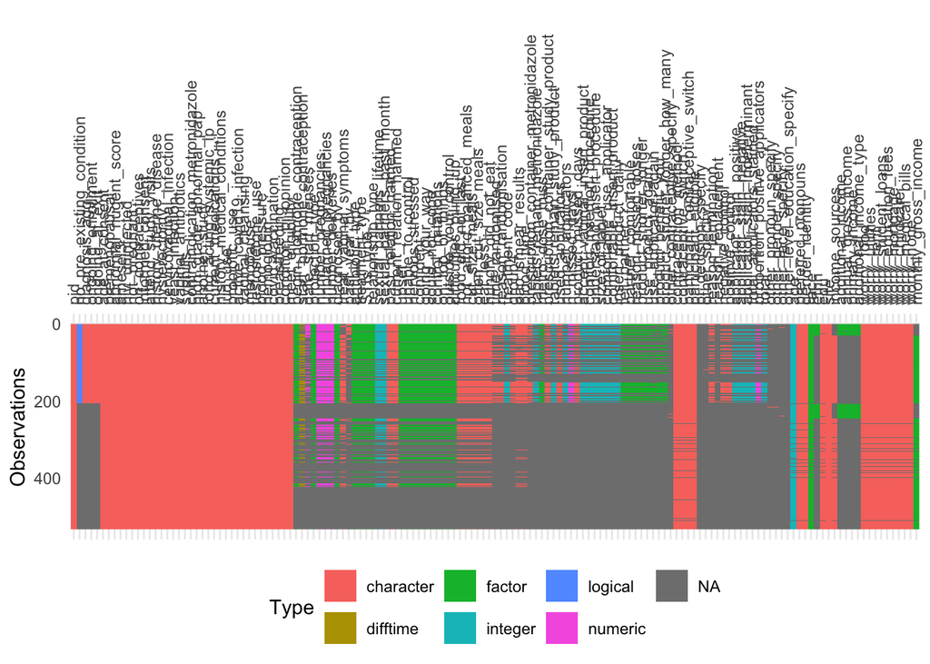

```r
visdat::vis_dat(participant_crfs_merged, sort_type = FALSE) +
  theme(
    legend.position = "bottom",
    axis.text.x = element_text(angle = 90, hjust = 0, vjust = 0.5)
  )
```

## Some QC

### BV diagnosed and treatment types

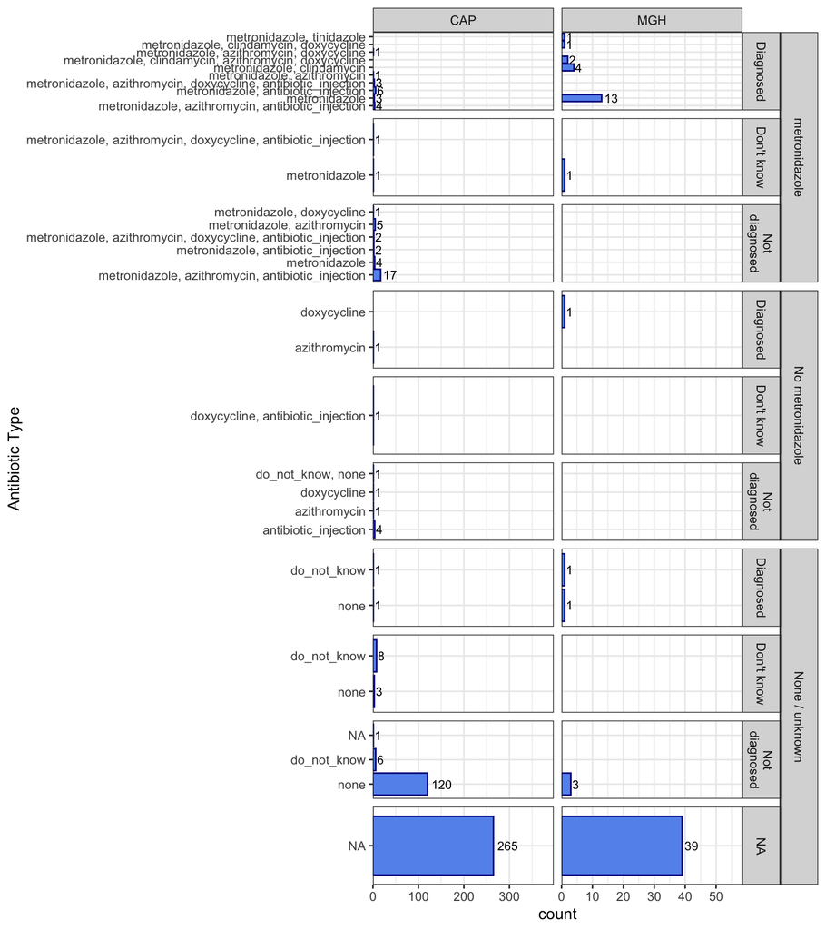

```r
participant_crfs_merged |>
  mutate(
    site = ifelse(str_detect(pid, "06810"), "MGH", "CAP"),
    metronidazole = case_when(
      str_detect(antibiotic_type, "metronidazole") ~ "metronidazole",
      antibiotic_type %in% c(NA, "none", "do_not_know", "do_not_know, no") ~ "None / unknown",
      TRUE ~ "No metronidazole"
    ),
    diagnosed_bv = case_when(
      diagnosed_bv == "Yes" ~ "Diagnosed",
      diagnosed_bv == "No" ~ "Not\ndiagnosed",
      TRUE ~ diagnosed_bv
    )
  ) |>
  ggplot() +
  aes(y = antibiotic_type) +
  geom_bar(color = "darkblue", fill = "cornflowerblue") +
  geom_text(
    stat = "count",
    aes(label = ..count..),
    hjust = -0.2,
    color = "black",
    size = 3
  ) +
  ggh4x::facet_nested(
    cols = vars(site),
    rows = vars(metronidazole, diagnosed_bv),
    scales = "free"
  ) +
  #facet_grid(diagnosed_bv~site, scale = "free") +
  labs(y = "Antibiotic Type") +
  scale_x_continuous(expand = expansion(mult = c(0, 0.5)))
```

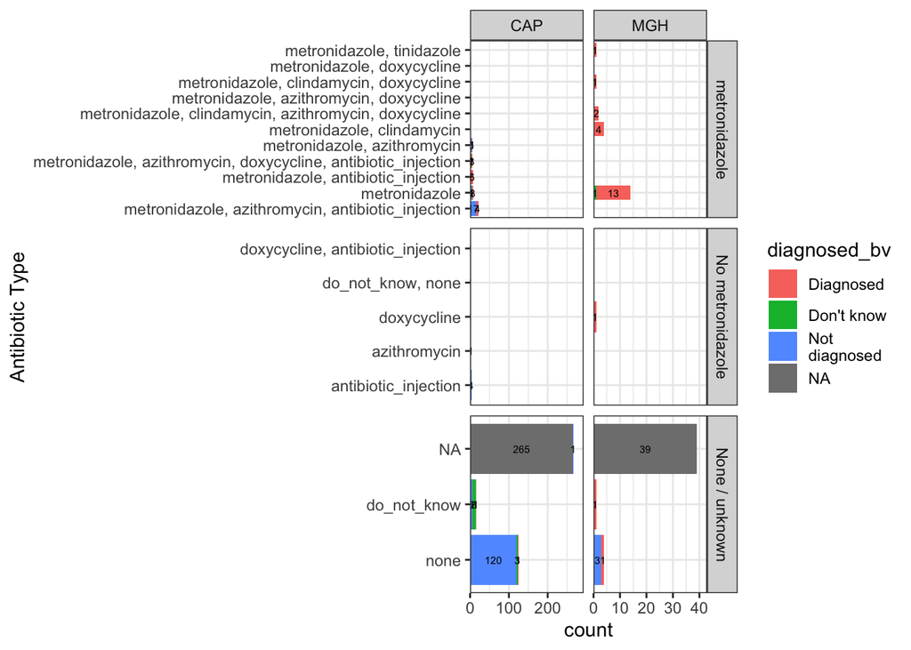

```r
participant_crfs_merged |>
  mutate(
    site = ifelse(str_detect(pid, "06810"), "MGH", "CAP"),
    metronidazole = case_when(
      str_detect(antibiotic_type, "metronidazole") ~ "metronidazole",
      antibiotic_type %in% c(NA, "none", "do_not_know", "do_not_know, no") ~ "None / unknown",
      TRUE ~ "No metronidazole"
    ),
    diagnosed_bv = case_when(
      diagnosed_bv == "Yes" ~ "Diagnosed",
      diagnosed_bv == "No" ~ "Not\ndiagnosed",
      TRUE ~ diagnosed_bv
    )
  ) |>
  ggplot() +
  aes(y = antibiotic_type, fill = diagnosed_bv) +
  geom_bar() +
  geom_text(
    stat = "count",
    aes(label = ..count..),
    position = position_stack(vjust = 0.5),
    #hjust = -0.1,
    color = "black",
    size = 2
  ) +
  facet_grid(metronidazole ~ site, scale = "free") +
  labs(y = "Antibiotic Type") +
  scale_x_continuous(expand = expansion(mult = c(0, 0.1)))
```

### BV diagnosed and other treatment type

[figure not shown]

```r
participant_crfs_merged |>
  mutate(
    site = ifelse(str_detect(pid, "06810"), "MGH", "CAP"),
    diagnosed_bv = case_when(
      diagnosed_bv == "Yes" ~ "Diagnosed",
      diagnosed_bv == "No" ~ "Not\ndiagnosed",
      TRUE ~ diagnosed_bv
    )
  ) |>
  ggplot() +
  aes(y = treatment_type, fill = diagnosed_bv) +
  geom_bar() +
  geom_text(
    stat = "count",
    aes(label = ..count..),
    position = position_stack(vjust = 0.5),
    #hjust = -0.1,
    color = "black",
    size = 2
  ) +
  facet_grid(~site, scale = "free") +
  labs(y = "Antibiotic Type") +
  scale_x_continuous(expand = expansion(mult = c(0, 0.1)))
```

# `visits_crfs_merged` table

We call “visit CRFs” any CRFs that was not present in the “participants CRFs” list. These CRFs were expected to contain potentially time-varying variables collected at multiple visits.

```r
visits_crf_name <-
  setdiff(
    names(crf_clean[!names(crf_clean) %in% c("crf1", "crf101", "crf2", "crf102")]),
    participants_crf_name
  ) |>
  setdiff("crf27_long")
```

CRF with no `study_day`

```r
#crf in visits_crf name but with no study_day variable
no_studyday <- crf_clean[names(crf_clean) %in% visits_crf_name] |>
  keep(~ !"study_day" %in% names(.x)) |>
  names()
no_studyday
```

```
[1] "crf17" "crf18" "crf19" "crf20" "crf21" "crf31" "crf33"
```

CRFs with no `visit_code`

```r
#crf in visits_crf name but with no dfseq variable
no_visit_code <- crf_clean[names(crf_clean) %in% visits_crf_name] |>
  keep(~ !"visit_code" %in% names(.x)) |>
  names()
no_visit_code
```

```
[1] "crf29_summary" "crf31"         "crf47_long"
```

CRFs used to create `visits_crfs_merges`table:

```r
visits_crf_name <-
  setdiff(visits_crf_name, no_visit_code) |>
  setdiff("crf29") |>
  setdiff("crf34")

visits_crf_name
```

```
 [1] "crf3"  "crf4"  "crf14" "crf16" "crf17" "crf18" "crf19" "crf20" "crf21"
[10] "crf26" "crf27" "crf30" "crf32" "crf33" "crf35" "crf40" "crf41" "crf42"
[19] "crf45" "crf47"
```

We now check that each CRF contains one row per participant and visit (i.e., per `uid`).

```r
map_df(
  visits_crf_name,
  function(visits_crf_name) {
    df <- crf_clean[[visits_crf_name]]

    if (!"uid" %in% names(df)) {
      return(tibble(crf = visits_crf_name, n_multi_uid = NA_integer_))
    }

    n <-
      df |>
      dplyr::count(uid) |>
      dplyr::filter(n > 1) |>
      nrow()

    tibble(crf = visits_crf_name, n_multi_uid = n)
  }
) |>
  gt()
```

| crf | n_multi_uid |
| --- | --- |
| crf3 | 0 |
| crf4 | 0 |
| crf14 | 1 |
| crf16 | 0 |
| crf17 | 0 |
| crf18 | 0 |
| crf19 | 0 |
| crf20 | 0 |
| crf21 | 0 |
| crf26 | 0 |
| crf27 | 0 |
| crf30 | 0 |
| crf32 | 0 |
| crf33 | 0 |
| crf35 | 0 |
| crf40 | 0 |
| crf41 | 0 |
| crf42 | 0 |
| crf45 | 0 |
| crf47 | 0 |

In CRF14, one `uid` (=068100002_0000) appears four times : two times with the same data and two times with incomplete data.

We keep one of the complete data and remove the two incomplete data.

```r
#crf14
uid_tmp <-
  crf_clean[["crf14"]] |>
  dplyr::count(uid) |>
  dplyr::filter(n > 1) |>
  pull(uid)

crf_clean[["crf14"]] |>
  dplyr::filter(uid %in% uid_tmp) |>
  group_by(uid) |>
  gt(row_group_as_column = TRUE)
```

|  | pid | visit_code | dfseq | vdate_fixed | study_day | clue_cells | whiff_test | vaginal_discharge | vaginal_ph | amsel_criteria | nugent_done | nugent_lactobacillus | nugent_gardenella | nugent_mobiluncus | nugent_total_score | nugent_flag_inconsistent |
| --- | --- | --- | --- | --- | --- | --- | --- | --- | --- | --- | --- | --- | --- | --- | --- | --- |
| 068100002_0000 | 068100002 | 0000 | 0 | FALSE | 0 | Negative | Negative | Present | 4.5 | 1 | Done | 1 | 4 | 0 | 5 | FALSE |
|  | 068100002 | 0000 | 0 | FALSE | 0 | Negative | Negative | Present | 4.5 | 1 | Done | 1 | 4 | 0 | 5 | FALSE |
|  | 068100002 | 0000 | 0 | FALSE | 0 | Negative | Negative | Present | 4.5 | 1 | Not done | NA | NA | NA | NA | NA |
|  | 068100002 | 0000 | 0 | FALSE | 0 | Negative | Negative | Present | 4.5 | 1 | Not done | NA | NA | NA | NA | NA |

```r
crf_clean[["crf14"]] <-
  crf_clean[["crf14"]] |>
  filter(!(uid == "068100002_0000" & nugent_done == "Not done")) |>
  distinct()
```

We join the CRFs to create the `visits_crfs_merged` table.

```r
# Some columns have the same name in different crf, we rename them by adding the crf name as suffix

crf_list_renamed <-
  crf_clean |>
  imap(function(df, name) {
    double_cols <- c(
      "vaginal_discharge",
      "vaginal_bleeding",
      "put_in_vagina_type",
      "sex_past_24hours",
      "page"
    )
    names(df)[names(df) %in% double_cols] <- paste0(
      names(df)[names(df) %in% double_cols],
      ".",
      name
    )
    df
  })


visits_crfs_merged <-
  crf_list_renamed[setdiff(visits_crf_name, no_studyday)] |>
  map(
    function(df) {
      df |> select(-any_of(c("uid", "vdate_fixed"))) #"uid",
    }
  ) |>
  purrr::reduce(full_join, by = join_by(pid, visit_code, dfseq, study_day))

# Then add crf with no study_day

visits_crfs_merged <-
  visits_crfs_merged |>
  full_join(
    crf_list_renamed[setdiff(no_studyday, no_visit_code)] |>
      map(
        function(df) {
          df |> select(-any_of(c("uid")))
        }
      ) |>
      purrr::reduce(full_join, by = join_by(pid, visit_code, dfseq)),
    by = join_by(pid, visit_code, dfseq)
  )
```

We remove data for which `hiv_result` is “missing” and for wich we have no other data.

```r
visits_crfs_merged <-
  visits_crfs_merged |>
  filter(
    !(hiv_results == "Missing" &
      nugent_done == "Missing" &
      if_all(-c(pid, visit_code, dfseq, hiv_results, nugent_done), is.na))
  ) |>
  distinct() |>
  mutate(uid = str_c(pid, "_", visit_code)) |>
  relocate(uid, pid, visit_code, study_day)
```

```r
visits_crfs_merged |>
  dplyr::count(uid) |>
  dplyr::filter(n > 1)
```

```
# A tibble: 97 × 2
   uid                n
   <chr>          <int>
 1 068100006_1000     2
 2 068100009_0000     2
 3 068100010_1100     2
 4 068100011_0000     2
 5 068100016_1100     2
 6 068100026_1200     2
 7 068100029_1100     2
 8 068100036_1511     2
 9 068100040_0000     2
10 068100040_1511     2
# ℹ 87 more rows
```

```r
## New sexual partner

visits_crfs_merged |>
  select(pid, visit_code, new_sex_partner)
```

[output not shown]

# Exports

```r
dir <- get_01_output_dir()

save(
  participant_crfs_merged,
  file = str_c(dir, "01_participant_crfs_merged_", today() |> str_replace_all("-", ""), ".Rdata")
)
save(
  visits_crfs_merged,
  file = str_c(dir, "01_visits_crfs_merged_", today() |> str_replace_all("-", ""), ".Rdata")
)
```